# 加固宏 ∗Fortifying Macros ∗

Ryan Culpepper † Matthias Felleisen

美国东北大学Northeastern University

{ryanc,matthias}@ccs.neu.edu

PDF · ICFP ’10 · 2010

## 摘要Abstract

现有宏系统迫使程序员在规约的清晰性与健壮性之间作出选择。如果选择清晰性，就必须放弃对规约中重要部分的验证，从而产生低质量的语言扩展。如果选择健壮性，就必须采用将实现与规约混杂在一起的编写风格，因而使后者晦涩难懂。Existing macro systems force programmers to make a choice between clarity of specification and robustness. If they choose clarity, they must forgo validating significant parts of the specification and thus produce low-quality language extensions. If they choose robustness, they must write in a style that mingles the implementation with the specification and therefore obscures the latter.

本文介绍一种用于编写宏的新语言。借助这一新的宏系统，程序员可以使用易于理解的规约，自然地编写健壮的语言扩展。该系统将这些规约转换为验证器，检测错误用法——包括违反上下文相关约束的用法——并自动合成恰当的反馈，从而无需编写临时拼凑的验证代码。This paper introduces a new language for writing macros. With the new macro system, programmers naturally write robust language extensions using easy-to-understand specifications. The system translates these specifications into validators that detect misuses—including violations of context-sensitive constraints— and automatically synthesize appropriate feedback, eliminating the need for ad hoc validation code.

类别与主题描述符 D.3.3 [程序设计语言]：语言构造与特性*Categories and Subject Descriptors* D.3.3 [*Programming Languages*]: Language Constructs and Features

一般术语 设计、语言*General Terms* Design, Languages

## 1. 什么是宏？1. What is a macro?

每一位函数式程序员都知道，`let` 表达式可以表示为对 `λ` 抽象的立即应用 [Landin 1965]。`let` 表达式的变量成为 `λ` 表达式的形参，初始化表达式成为应用的实参，而主体则成为 `λ` 表达式的主体。下面是这一思想的准形式化表述：Every functional programmer knows that a `let` expression can be expressed as the immediate application of a `λ` abstraction [Landin 1965]. The `let` expression’s variables become the formal parameters of the `λ` expression, the initialization expressions become the application’s arguments, and the body becomes the body of the `λ` expression. Here is a quasi-formal expression of the idea:

```
(let ([var rhs] ...) body) = ((λ (var ...) body) rhs ...)
```

这里约定，每个 `var` 都是标识符，每个 `rhs` 和 `body` 都是表达式；各变量还必须互不相同。这些约束可以作为上述等式的附加说明来陈述，其中一些甚至可能是元变量约定的自然结果。It is understood that each `var` is an identifier and each `rhs` and `body` is an expression; the variables also must be distinct. These constraints might be stated as an aside to the above equation, and some might even be a consequence of metavariable conventions.

像 `let` 这样的新语言元素可以通过宏来实现，宏能够自动将新的语言形式转换为更简单的形式。从本质上说，宏是一种用于扩展编译器前端的 API。然而，与许多语言扩展工具不同，宏是其所扩展语法的程序本身的一部分，不使用单独的预处理器。New language elements such as `let` can be implemented via *macros*, which automate the translation of new language forms into simpler ones. Essentially, macros are an API for extending the front end of the compiler. Unlike many language extension tools, however, a macro is part of the program whose syntax it extends; no separate pre-processor is used.

`∗`本研究部分由 NSF 基础设施资助项目支持。`†` 新地址：计算学院，50 Central Campus Drive（3190 室），Salt Lake City，UT 84112-9205`∗`The research was partially supported by NSF infrastructure grants. `†` New address: School of Computing, 50 Central Campus Drive (Rm 3190), Salt Lake City, UT 84112-9205

宏定义将一个名称与一个编译时函数关联起来，这个函数就是语法转换器。当编译器遇到宏名称的使用时，它会调用关联的宏转换器来重写该表达式。由于宏是通过转换来定义的，因此常被称为派生语法形式。在上面的例子中，派生形式 `let` 被展开为原始形式 `λ` 和函数应用。由于宏用法的语法受到限制——宏名称必须出现在运算符位置——语言扩展很容易组合。由于扩展依托于名称，因此可以通过控制名称的作用域来管理扩展。这使得逐层构建语言塔成为可能。A macro definition associates a name with a compile-time function, i.e., a *syntax transformer*. When the compiler encounters a use of the macro name, it calls the associated macro transformer to rewrite the expression. Because macros are defined by translation, they are often called *derived syntactic forms*. In the example above, the derived form `let` is expanded into the primitive forms `λ` and function application. Due to the restricted syntax of macro uses— the macro name must occur in operator position—extensions to the language easily compose. Since extensions are anchored to names, extensions can be managed by controlling the scope of their names. This allows the construction of a tower of languages in layers.

引入称为宏的新语言元素，长期以来一直是每位 Lisp 和 Scheme 程序员的标准技能。Racket [Flatt and PLT 2010] 原名 PLT Scheme，是 Lisp 和 Scheme 的后继语言，其标准库广泛使用宏。部分出于教学用途的需要，Racket 对错误行为有很高的要求。使用宏构建的语言也必须达到与 Racket 本身相同的标准。具体而言，应当针对程序员所犯的错误来报告语法错误，而不是报告经过若干轮重写后才发现的错误；此外，还应当使用语言扩展文档中规定的术语来报告错误。Introducing new language elements, dubbed *macros*, has long been a standard element of every Lisper’s and Schemer’s repertoire. Racket [Flatt and PLT 2010], formerly PLT Scheme, is a descendent of Lisp and Scheme that uses macros pervasively in its standard libraries. Due in part to its pedagogical uses, Racket has high standards for error behavior. Languages built with macros are held to the same standards as Racket itself. In particular, syntactic mistakes should be reported in terms of the programmer’s error, not an error discovered after several rounds of rewriting; and furthermore, the mistake should be reported in terms documented by the language extension.

遗憾的是，使用现有系统，要编写既易于理解、又能正确验证自身语法的宏，其困难程度出乎意料。这些系统迫使程序员将语法和语义的声明式规约与极其细致的验证代码混杂在一起。然而，没有验证，宏就不是真正的抽象。相反，错误的项会一路通过解析过程，直到最终触发语言塔底层的约束检查。底层检查又会产生令人费解的错误消息，让程序员不得不四处寻找解释。简言之，这样的宏并没有创造无缝衔接的语言抽象，反而成了困惑与干扰的来源。Sadly, existing systems make it surprisingly difficult to produce easy-to-understand macros that properly validate their syntax. These systems force the programmer to mingle the declarative specification of syntax and semantics with highly detailed validation code. Without validation, however, macros aren’t true abstractions. Instead, erroneous terms flow through the parsing process until they eventually trip over constraint checks at a low level in the language tower. Low-level checking, in turn, yields incoherent error messages and leaves programmers searching for explanations. In short, such macros do not create seamless linguistic abstractions but sources of confusion and distraction.

本文提出一种面向 Racket 的新型宏系统，使真正的语法抽象得以建立。程序员定义模块化、可复用的语法规约，并用它们来验证宏的用法。这些规约由加入上下文相关约束的文法组成。当宏使用不当时，宏系统会利用规约，在恰当的抽象层次上合成错误消息。In this paper, we present a novel macro system for Racket that enables the creation of true syntactic abstractions. Programmers define modular, reusable specifications of syntax and use them to validate uses of macros. The specifications consist of grammars extended with context-sensitive constraints. When a macro is used improperly, the macro system uses the specifications to synthesize an error message at the proper level of abstraction.

## 2. 表达宏2. Expressing macros

为说明现有宏系统的问题，让我们结合随处可见的 `let` 示例来考察它们：To illustrate the problems with existing macro systems, let us examine them in the context of the ubiquitous `let` example:

```
(let ([var rhs] ...) body) = ((λ (var ...) body) rhs ...)
```

各 `var` 是互不相同的标识符 `body`，各 `rhs` 是表达式the `var`s are distinct identifiers `body` and the `rhs`s are expressions

宏的语法转换器本质上是从语法到语法的函数。许多 Lisp 方言将此视为接口的全部：宏不过是一类特殊函数，用 `define-macro` 而不是 `define` 引入，接收并产生表示项的 S 表达式。这类系统中的宏通常使用标准的 S 表达式函数来“解析”语法，并使用准引用来构建去糖后的表达式：A macro’s syntax transformer is essentially a function from syntax to syntax. Many Lisp dialects take that as the entirety of the interface: macros are just distinguished functions, introduced with `define-macro` instead of `define`, that consume and produce S-expressions representing terms. Macros in such systems typically use standard S-expression functions to “parse” syntax, and they use quasiquotation to build up the desugared expression:

```
(define-macro (let bindings body)
  `((λ ,(map first bindings) ,body)
    ,@(map second bindings)))
```

组织良好的实现会先提取子项并为其命名，再组装结果，从而将解析与代码生成分离：A well-organized implementation would extract and name the sub-terms before assembling the result, separating *parsing* from *code* *generation*:

```
(define-macro (let bindings body)
  (define vars (map first bindings))
  (define rhss (map second bindings))
  `((λ ,vars ,body) ,@rhss))
```

然而，这些定义并不像规约，甚至没有正确实现规约。解析代码没有验证 `let` 的基本语法。例如，该宏会直接忽略绑定对中多余的项：These definitions do not resemble the specification, however, and they do not even properly implement it. The parsing code does not validate the basic syntax of `let`. For example, the macro simply ignores extra terms in a binding pair:

```
(let ([x 1] [y 3 "what about me?"]) (+ x y))
```

宏编写者往往急于在“能用了”之后立即继续下一项工作；除非工具让健壮的宏易于编写，否则他们仍会编写这种草率的宏。Macro writers, eager to move on as soon as “it works,” will continue to write sloppy macros like these unless their tools make it easy to write robust ones.

一种这样的工具是 Kohlbecker 和 Wand [1987] 所提出的所谓 Macro-By-Example（MBE，示例式宏）记法。在 MBE 中，宏使用接近最初非形式化等式的记法来规定，而解析与转换代码则自动生成。生成的解析代码强制执行所声明的语法，拒绝上述那样格式错误的用法。One such tool is the so-called Macro-By-Example (MBE) notation by Kohlbecker and Wand [1987]. In MBE, macros are specified in a notation close to the initial informal equation, and the parsing and transformation code is produced automatically. The generated parsing code enforces the declared syntax, rejecting malformed uses such as the one above.

MBE 用一系列子句替代过程式代码，每个子句由一个模式和一个模板组成。模式描述宏的语法。模式中包含语法`pattern`变量；当模式匹配成功时，模式变量会绑定到宏出现处相应的子项。这些子项被替换到模板中模式变量出现的位置，从而产生宏的展开结果。MBE replaces the procedural code with a sequence of clauses, each consisting of a pattern and a template. The patterns describe the macro’s syntax. A pattern contains *syntax* `pattern` *variables*, and when a pattern matches, the pattern variables are bound to the corresponding sub-terms of the macro occurrence. These sub-terms are substituted into the template where the pattern variables occur to produce the macro’s expansion result.

下面使用 `syntax-rules` [Sperber et al. 2009] 来表达 `let`；前者是 MBE 的众多实现之一：Here is `let` expressed with `syntax-rules` [Sperber et al. 2009], one of many implementations of MBE:

```
(define-syntax let
  (syntax-rules ()
    [(let ([var rhs] ...) body)
     ((λ (var ...) body) rhs ...)]))
```

模式变量是 `var`、`rhs` 和 `body`。The pattern variables are `var`, `rhs`, and `body`.

MBE 的关键创新是使用省略号（. . .）来描述具有同质结构的子项序列。这种序列在 S 表达式语法中经常出现。有些序列的元素很简单，例如 `λ` 表达式的参数；但序列往往具有非平凡的结构，例如将 `let` 绑定的变量与其值关联起来的绑定对。The crucial innovation of MBE is the use of ellipses (. . .) to describe sequences of sub-terms with homogeneous structure. Such sequences occur frequently in S-expression syntax. Some sequences have simple elements, such as the parameters of a `λ` expression, but often the sequences have non-trivial structure, such as binding pairs associating `let`-bound variables with their values.

每个模式变量都有一个关联的省略号深度。深度为 0 表示变量包含单个项，深度为 1 表示项的列表，以此类推。语法模板会经过静态检查，以确保省略号深度一致。本文不讨论模板检查和转写；详见 Kohlbecker and Wand [1987]。Every pattern variable has an associated *ellipsis depth*. A depth of 0 means the variable contains a single term, a depth of 1 indicates a list of terms, and so on. Syntax templates are statically checked to make sure the ellipsis depths are consistent. We do not address template checking and transcription in this work; see Kohlbecker and Wand [1987] for details.

省略号没有增强宏系统的表达能力，却增强了模式的表现力。没有省略号，仍然可以通过显式递归来表达 `let` 宏，但这种方式会掩盖合法 `let` 表达式的本质；其描述不再集中于单个模式，而是分散在递归宏的多个子句中。简言之，省略号有助于缩小规约与实现之间的差距。Ellipses do not add expressive power to the macro system but do add expressiveness to *patterns*. Without ellipses, the `let` macro can still be expressed via explicit recursion, but in a way that obscures the nature of valid `let` expressions; instead of residing in a single pattern, it would be distributed across multiple clauses of a recursive macro. In short, ellipses help close the gap between specification and implementation.

然而，MBE 无法表达上述 `let` 非形式化描述中的全部信息。迄今给出的示例宏都忽略了对 `let` 语法两个关键方面的验证：每个绑定对的第一项必须是标识符，而且这些标识符必须互不相同。Yet MBE lacks the power to express all of the information in the informal description of `let` above. The example macros presented so far neglect to validate two critical aspects of the `let` syntax: the first term of each binding pair must be an identifier, and those identifiers must be distinct.

考虑 `let` 的以下两种错误用法：Consider these two misuses of `let`:

```
(let ([x 1] [x 2]) (+ x x))
(let ([(x y) (f 7)]) (g x y))
```

在这两种情况下，`let` 宏都没有报告自己被错误使用。两次它都检查语法、判定其通过，并产生一个无效的 `λ` 表达式。随后，由细心的编译器编写者实现的 `λ` 才会发出错误信号，例如，对于第一个项，Racket 会报告“`λ`: duplicate identifier in: `x`”；对于第二个项，Chez Scheme [Cadence Research Systems 1994] 会报告“invalid parameter list in (`λ` ((x y)) (`g` `x` `y`))”。在提供源位置跟踪功能 [Dybvig et al. 1993] 的宏系统中，这一功能可以在一定程度上改善状况。例如，DrRacket [Findler et al. 2002] 编程环境会突出显示重复的标识符。但这并不是一个好的解决方案。宏应当以自身的术语来报告错误。In neither case does the `let` macro report that it has been used incorrectly. Both times it inspects the syntax, approves it, and produces an invalid `λ` expression. Then `λ`, implemented by a careful compiler writer, signals an error, such as “`λ`: duplicate identifier in: `x`” in Racket for the first term and “invalid parameter list in (`λ` ((*x y*)) (`g` `x` `y`))” in Chez Scheme [Cadence Research Systems 1994] for the second. Source location tracking [Dybvig et al. 1993] improves the situation somewhat in macro systems that offer it. For example, the DrRacket [Findler et al. 2002] programming environment highlights the duplicate identifier. But this is not a good solution. Macros should report errors on their own terms.

更糟糕的是，宏可能会放行具有非预期含义的语法。在 Racket 中，上面的第二个示例会产生令人意外的错误“unbound variable in: `y`”。其中的对 (`x` `y`) 被当作带有默认表达式的可选参数而接受，这是 Racket 的 `λ` 语法的一项特性；错误所指的是后半部分中的自由变量 `y`。如果 `y` 在这个上下文中已有绑定，第二个示例就会被悄然接受。稍作变化便可展示另一个陷阱：Worse, a macro might pass through syntax that has an unintended meaning. In Racket, the second example above produces the surprising error “unbound variable in: `y`.” The pair (`x` `y`) is accepted as an *optional parameter with a default expression*, a feature of Racket’s `λ` syntax, and the error refers to the free variable `y` in the latter portion. If `y` were bound in this context, the second example would be silently accepted. A slight variation demonstrates another pitfall:

```
(let ([(x) (f 7)]) (g x x))
```

这一次，Racket 报告以下错误：“`λ`: not an identifier, identifier with default, or keyword at: (`x`).”这条错误消息不仅泄露了 `let` 的实现，还间接掩盖了 `let` 的合法语法。This time, Racket reports the following error: “`λ`: not an identifier, identifier with default, or keyword at: (`x`).” The error message not only leaks the implementation of `let`, it implicitly obscures the legal syntax of `let`.

```
(define-syntax (let stx)
  (syntax-case stx ()
    [(let ([var rhs] ...) body)
     ;; Guard expression
     (and (andmap identifier? (syntax->list #'(var ...)))
          (not (check-duplicate #'(var ...))))
     ;; Transformation expression
     #'((λ (var ...) body) rhs ...)]))
```

图 1. 带守卫的 letFigure 1. let with guards

这一问题的传统解决方案是加入守卫表达式，有时也称为 fender；它在模式匹配成功之后、转换表达式求值之前运行。守卫表达式产生真或假，以表示其约束是否得到满足。如果守卫表达式失败，就拒绝该模式并尝试下一个模式。如果所有模式都失败，宏就会引发一个笼统的语法错误，例如“语法错误”。The traditional solution to this problem is to include a guard expression, sometimes called a *fender*, that is run after the pattern matches but before the transformation expression is evaluated. The guard expression produces true or false to indicate whether its constraints are satisfied. If the guard expression fails, the pattern is rejected and the next pattern is tried. If all of the patterns fail, the macro raises a *generic syntax error*, such as “bad syntax.”

图 1 展示了用 `syntax-case` [Dybvig et al. 1993; Sperber et al. 2009] 实现的 `let`；前者是提供守卫表达式的 MBE 实现。一个 `syntax-case` 子句由模式、可选的守卫以及转换表达式组成。表达式内的语法模板用 `#’` 前缀标记。Figure 1 shows the implementation of `let` in `syntax-case` [Dybvig et al. 1993; Sperber et al. 2009], an implementation of MBE that provides guard expressions. A `syntax-case` clause consists of a pattern, an optional guard, and a transformation expression. Syntax templates within expressions are marked with a `#’` prefix.

守卫表达式足以防止宏接受无效语法，但它们有两个缺陷。首先，由于守卫表达式与转换表达式相互分离，验证和转换共同需要的工作必须执行两次，代码也常常重复。其次，更重要的是，守卫不解释语法为何无效。也就是说，它们只控制匹配，不跟踪失败的原因。Guard expressions suffice to prevent macros from accepting invalid syntax, but they suffer from two flaws. First, since guard expressions are separated from transformation expressions, work needed both for validation and transformation must be performed *twice* and code is often duplicated. Second and more important, guards do *not* explain why the syntax was invalid. That is, they only control matching; they do not track causes of failure.

```
(define-syntax (let stx)
  (syntax-case stx ()
    [(let ([var rhs] ...) body)
     (begin
       ;; Error-checking code
       (for-each (λ (var)
                   (unless (identifier? var)
                     (syntax-error "expected identifier" stx var)))
                 (syntax->list #'(var ...)))
       (let ([dup (check-duplicate #'(var ...))])
         (when dup
           (syntax-error "duplicate variable name" stx dup)))
       ;; Result term
       #'((λ (var ...) body) rhs ...))]))
```

图 2. 带手写错误检查的 letFigure 2. let with hand-coded error checking

为了提供准确的错误解释，必须进行显式错误检查，如图 2 所示。在该宏子句的十行非注释代码中，一行是模式，一行是模板，八行专用于验证。此外，这个宏只报告形状与模式相符的错误。如果给它一个格式错误的绑定对，其中右侧表达式后还有多余的项，那么该子句就无法匹配，`syntax-case` 会产生一个笼统的错误。检测和报告此类错误需要更多代码。恐怕只有最尽责的宏编写者才会花时间枚举语法可能无效的所有方式，并给出适当的错误报告。To provide precise error explanations, explicit error checking is necessary, as shown in figure 2. Of the ten non-comment lines of the macro’s clause, one is the pattern, one is the template, and *eight* are dedicated to validation. Furthermore, this macro only reports errors that match the shape of the pattern. If it is given a malformed binding pair with extra terms after the right-hand side expression, the clause fails to match, and `syntax-case` produces a generic error. Detecting and reporting those sorts of errors would require even more code. Only the most conscientious macro writers are likely to take the time to enumerate all the ways the syntax could be invalid and to issue appropriate error reports.

当然，`let` 的代码可以简化。宏编写者可以构建常用错误检查例程的库。然而，这种方法仍会将错误检查代码与转换代码混杂在一起，掩盖 `let` 原本自然的两行规约。此外，专注于引发语法错误的抽象无法解决守卫的另一个用途，即在多个有效备选项之间进行选择。Certainly, the code for `let` could be simplified. Macro writers could build libraries of common error-checking routines. Such an approach, however, would still obscure the natural two-line specification of `let` by mixing the error-checking code with the transformation code. Furthermore, abstractions that focus on raising syntax errors would not address the other purpose of guards, the selection among multiple valid alternatives.

即使忽略错误报告的细微之处，有些语法也确实难以用 MBE 模式来解析。宏编写者有两种应对方式：要么采用简化的语法，牺牲用户的便利性；要么手写解析器。Even ignoring the nuances of error reporting, some syntax is simply difficult to parse with MBE patterns. Macro writers cope in two ways: either they compromise on the user’s convenience with simplified syntax or they hand-code the parser.

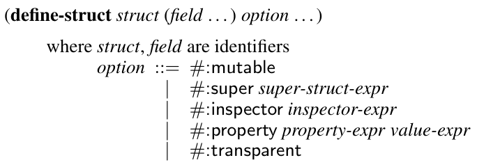

其中 struct、field 是标识符where struct, field are identifiers

图 3. define-struct 的语法Figure 3. The syntax of define-struct

关键字实参就是一种难以使用 MBE 模式解析的语法。Racket 的 `define-struct` 形式是增强了关键字功能的宏的一个示例，其文法见图 3。它具有多个关键字选项，可以按任意顺序出现。`#:transparent` 和 `#:inspector` 关键字控制何时可以通过反射检查结构值。`#:mutable` 选项使字段可变；`#:property` 选项允许结构类型覆盖其行为，例如打印方式；诸如此类。不同关键字携带的实参数量也不同，例如，`#:mutable` 不带实参，而 `#:property` 带两个实参。Keyword arguments are one kind of syntax difficult to parse using MBE patterns. An example of a keyword-enhanced macro is Racket’s `define-struct` form, whose grammar is specified in figure 3. It has several keyword options, which can occur in any order. The `#:transparent` and `#:inspector` keywords control when structure values can be inspected via reflection. The `#:mutable` option makes the fields mutable; the `#:property` option allows structure types to override behavior such as how they are printed; and so on. Different keywords come with different numbers of arguments, e.g., `#:mutable` has none and `#:property` takes two.

优雅地解析 `define-struct` 形式，完全超出了 MBE 模式语言的能力范围，因为后者关注的是同质序列。要支持单个可选关键字实参，只需编写两个子句——一个有该实参，一个没有。当有两个实参时，推算出所有模式就变得繁重，宏编写者很可能作出古怪的权宜妥协——要求实参必须按某种顺序出现，或者一旦给出一个实参，就必须两个都给出。超过两个实参，这种方法就行不通了。替代办法依然是将一部分解析工作移入转换器代码。宏编写者先用模式粗略勾勒语法的大体结构，再用过程式解析代码补全细节：Parsing a `define-struct` form gracefully is simply beyond the capabilities of MBE’s pattern language, which focuses on homogeneous sequences. A single optional keyword argument can be supported by simply writing two clauses—one with the argument and one without. At two arguments, calculating out the patterns becomes onerous, and the macro writer is likely to make odd, expedient compromises—arguments must appear in some order, or if one argument is given, both must be. Beyond two arguments, the approach is unworkable. The alternative is, again, to move part of the parsing into the transformer code. The macro writer sketches the rough structure of the syntax in broad strokes with a pattern, then fills in the details with procedural parsing code:

```
(define-syntax (define-struct stx)
  (syntax-case stx ()
    [(define-struct name (field ...) kw-options ...)
     —— #'(kw-options ...) ——]))
```

在 `define-struct` 的实际实现中，仅解析关键字选项就需要一百多行代码。相比之下，改用我们的新系统来表述后，这部分代码缩短了一个数量级。In the actual implementation of `define-struct`, the parsing of keyword options alone takes over one hundred lines of code. In comparison, when formulated in our new system this code is shortened by an order of magnitude.

总之，MBE 提供的语法模式能力薄弱，迫使程序员将验证与错误报告工作移入守卫和转换器。此外，守卫表达式接受或拒绝的是整个子句，而拒绝时并不提供守卫为何失败的信息。最后，MBE 缺乏描述许多重要语法的词汇。我们为宏设计的新领域特定语言消除了这些问题。In summary, MBE offers weak syntax patterns, forcing the programmer to move the work of validation and error-reporting into guards and transformers. Furthermore, guard expressions accept or reject entire clauses, and rejection comes without information as to why the guard failed. Finally, MBE lacks the vocabulary to describe a broad range of important syntaxes. Our new domain-specific language for macros eliminates these problems.

## 3. syntax-parse 的设计3. The design of syntax-parse

我们的系统名为 `syntax-parse`，使用领域特定语言来支持解析、验证和错误报告。与 MBE 相比，它有三项重大改进：Our system, dubbed `syntax-parse`, uses a domain-specific language to support parsing, validation, and error reporting. It features three significant improvements over MBE:

- `•` 一种表现力丰富的语法模式语言，其中模式变量标注了它们能够匹配的语法类；`•` an expressive language of syntax patterns, including pattern variables annotated with the classes of syntax they can match;
- `•` 一种用于定义新语法类的机制，将语法类作为语法模式之上的抽象；以及`•` a facility for defining new syntax classes as abstractions over syntax patterns; and
- `•` 一种跟踪进度以对失败进行排序和报告的匹配算法，以及一种携带错误信息的失败概念。`•` a matching algorithm that tracks progress to rank and report failures and a notion of failure that carries error information.

此外，守卫表达式被替换为附加条件，后者会提供拒绝消息。Furthermore, guard expressions are replaced with *side conditions*, which provide rejection messages.

新系统中的语法类扮演着类似于传统文法中非终结符的角色。它们的加入，使声明式规约与手写检查得以有条理地交织使用。The syntax classes of our new system serve a role similar to that of non-terminals in traditional grammars. Their addition allows the disciplined interleaving of declarative specifications and hand-coded checks.

本节通过一系列基于 `let` 示例的例子，说明 `syntax-parse` 的设计。This section illustrates the design of `syntax-parse` with a series of examples based on the `let` example.

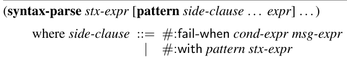

图 4. syntax-parse 的语法Figure 4. Syntax of syntax-parse

### 3.1 验证语法3.1 Validating syntax

`syntax-parse` 的语法如图 4 所示，与 `syntax-case` 类似。作为起点，下面给出从 `syntax-rules` 版本直接改写而来的 `let` 宏：The syntax of `syntax-parse`—specified in figure 4—is similar to `syntax-case`. As a starting point, here is the `let` macro transliterated from the `syntax-rules` version:

```
(define-syntax (let stx)
  (syntax-parse stx
    [(let ([var rhs] ...) body)
     #'((λ (var ...) body) rhs ...)]))
```

我们在这个框架上加入约束，要求每个标为 `var` 的项都必须是标识符。同样，为 `rhs` 和 `body` 添加标注，表明它们是表达式。就我们的用途而言，表达式是关键字以外的任何项。最后一个约束，即标识符互不重复的要求，则通过 `#:fail-when` 子句表达为附加条件。下面是修改后的宏：To this skeleton we add the constraint that every term labeled `var` must be an identifier. Likewise, `rhs` and `body` are annotated to indicate that they are expressions. For our purposes, an expression is any term other than a keyword. The final constraint, that the identifiers are unique, is expressed as a side condition using a `#:fail-when` clause. Here is the revised macro:

```
(define-syntax (let stx)
  (syntax-parse stx
    [(let ([var:identifier rhs:expr] ...) body:expr)
     #:fail-when (check-duplicate #'(var ...))
     "duplicate variable name"
     #'((λ (var ...) body) rhs ...)]))
```

注意，像 `expr` 这样的语法类标注并不是模式变量名称的一部分，也不会出现在模板中。Note that a syntax class annotation such as `expr` is not part of the pattern variable name, and it does not appear in the template.

对 check-duplicate 的调用充当条件；如果结果为假，就不会发生失败，控制流会转到模板表达式。但如果它返回任何其他值，解析就会失败，并给出“变量名重复”的消息；此外，如果条件值是语法对象——即项的表示——那么该语法也会被包含在报告中，作为失败的具体位置。简言之，附加条件不同于守卫表达式之处在于，它们所产生的失败携带着描述失败原因的信息。The call to *check-duplicate* acts as a condition; if it is false, failure is averted and control flows to the template expression. But if it returns any other value, parsing fails with a “duplicate variable name” message; furthermore, if the condition value is a syntax object—that is, the representation of a term—that syntax is included as the specific site of the failure. In short, side conditions differ from guard expressions in that the failures they generate carry information describing the reasons for the failure.

至此，我们的 `let` 宏能够正确验证其语法。它能捕获前述错误用法，并报告以下错误：At this point, our `let` macro properly validates its syntax. It catches the misuses earlier and reports the following errors:

```
> (let ([x 1] [x 2]) (h x))
let: duplicate variable name in: x
> (let ([(x y) (f 7)]) (g x y))
let: expected identifier in: (x y)
```

方框标明了问题的具体位置；DrRacket 编程环境除了打印错误消息，还会将这些项以红色突出显示。The boxes indicates the specific location of the problem; the Dr- Racket programming environment highlights these terms in red in addition to printing the error message.

对于某些错误用法，`let` 仍无法提供良好的错误消息。下面是一个缺少一对括号的示例：For some misuses, `let` still doesn’t provide good error messages. Here is an example that is missing a pair of parentheses:

```
> (let (x 5) (add1 x))
let: bad syntax
```

我们的 `let` 宏以一条笼统的错误消息拒绝这种错误用法。要获得更好的错误消息，宏编写者必须向 `syntax-parse` 提供额外信息。Our `let` macro rejects this misuse with a generic error message. To get better error messages, the macro writer must supply `syntax-parse` with additional information.

### 3.2 定义语法类3.2 Defining syntax classes

语法类构成了 `syntax-parse` 错误报告机制的基础。为绑定对定义语法类，就赋予了 `syntax-parse` 解释一类新错误所需的词汇。绑定对的语法可定义为如下语法类：Syntax classes form the basis of `syntax-parse`’s error-reporting mechanism. Defining a syntax class for binding pairs gives `syntax-parse` the vocabulary to explain a new class of errors. The syntax of binding pairs is defined as a syntax class thus:

```
(define-syntax-class binding
  #:description "binding pair"
  (pattern [var:identifier rhs:expr]))
```

该语法类名为 binding，但在错误报告中称为“绑定对”。由于模式变量 `var` 和 `rhs` 已从主模式移入语法类，必须将它们作为语法类的属性导出，以便主模式能够访问它们的绑定。带有 binding 标注的模式变量名称 `b` 与属性名组合，形成嵌套属性 b.var 和 b.rhs：The syntax class is named *binding*, but for the purposes of error reporting it is known as “binding pair.” Since the pattern variables `var` and `rhs` have moved out of the main pattern into the syntax class, they must be exported as *attributes* of the syntax class so that their bindings are available to the main pattern. The name of the *binding*-annotated pattern variable, `b`, is combined with the names of the attributes to form the *nested attributes b.var* and *b.rhs*:

```
(define-syntax (let stx)
  (syntax-parse stx
    [(let (b:binding ...) body:expr)
     #:fail-when (check-duplicate #'(b.var ...))
     "duplicate variable name"
     #'((λ (b.var ...) body) b.rhs ...)]))
```

宏往往共享常见的语法结构。例如，绑定对语法由表示变量名的标识符和表示其值的表达式组成，也出现在 `let` 的其他变体中，如 `let∗` 和 `letrec`。Macros tend to share common syntactic structure. For example, the binding pair syntax, consisting of an identifier for the variable name and an expression for its value, occurs in other variants of `let`, such as `let∗` and `letrec`.

除了模式，语法类还可以包含附加条件。例如，`let` 和 `letrec` 形式都要求变量绑定互不相同。下面是一个适用的语法类：In addition to patterns, syntax classes may contain side conditions. For example, both the `let` and `letrec` forms require that their variable bindings be distinct. Here is an appropriate syntax class:

```
(define-syntax-class distinct-bindings
  #:description "sequence of binding pairs"
  (pattern (b:binding ...)
    #:fail-when (check-duplicate #'(var ...))
    "duplicate variable name"
    #:with (var ...) #'(b.var ...)
    #:with (rhs ...) #'(b.rhs ...)))
```

distinct-bindings 的属性是 `var` 和 `rhs`。它们由 `#:with` 子句绑定，每个子句都由模式及其后的表达式组成，表达式可以引用先前绑定的属性，例如 b.var。表达式的结果会与模式匹配，而该模式的属性可以导出，也可以供后续附加子句使用。与 binding 的 `var` 和 `rhs` 属性不同，distinct-bindings 的 `var` 和 `rhs` 属性的省略号深度为 1，因此即使 `bs` 在宏模式中没有出现在省略号之内，bs.var 和 bs.rhs 也可以在宏模板的省略号内使用：The attributes of *distinct-bindings* are `var` and `rhs`. They are bound by the `#:with` clauses, each of which consists of a pattern followed by an expression, which may refer to previously bound attributes such as *b.var*. The expression’s result is matched against the pattern, and the pattern’s attributes are available for export or for use by subsequent side clauses. Unlike the `var` and `rhs` attributes of *binding*, the `var` and `rhs` attributes of *distinct-bindings* have an *ellipsis depth* of 1, so *bs.var* and *bs.rhs* can be used within ellipses in the macro’s template, even if `bs` does not occur within ellipses in the macro’s pattern:

```
(define-syntax (let stx)
  (syntax-parse stx
    [(let bs:distinct-bindings body:expr)
     #'((λ (bs.var ...) body) bs.rhs ...)]))
```

现在，我们已经规定了 binding 和 distinctbindings 的语法，`syntax-parse` 可以利用它们，为 `let` 的更多错误用法生成良好的错误消息：Now that we have specified the syntax of *binding* and *distinctbindings*, `syntax-parse` can use them to generate good error message for additional misuses of `let`:

```
> (let (x 5) (add1 x))
let: expected binding pair in: x
> (let 17)
let: expected sequence of binding pairs in: 17
```

下一节说明 `syntax-parse` 如何生成错误消息，以及定义语法类如何影响错误报告。The next section explains how `syntax-parse` generates error messages and how defining syntax classes affects error reporting.

## 4. 报告错误4. Reporting errors

`syntax-parse` 系统使用宏语法的声明式规约，来报告宏用法中的错误。错误报告任务分为两步。首先，匹配算法选择最适合报告的错误。其次，通过精确指出有问题的项，并描述问题或说明预期的语法类，来报告错误。The `syntax-parse` system uses the declarative specification of a macro’s syntax to report errors in macro uses. The task of reporting errors is factored into two steps. First, the matching algorithm selects the most appropriate error to report. Second, it reports the error by pinpointing the faulty term and describing the fault or stating the expected class of syntax.

### 4.1 错误选择4.1 Error selection

模式变量标注和附加条件在我们的系统中具有双重作用。如前所述，模式变量标注和附加条件使 `syntax-parse` 能够验证语法。当验证失败时，`syntax-parse` 会报告失败的具体位置和原因。但标注与附加条件的行为并不只是像图 2 中的错误检查那样。宏可以有多个子句，语法类也可以有多个变体。如果存在多个选择，就必须在引发并解释错误之前尝试所有选择。Pattern variable annotations and side conditions serve a dual role in our system. As seen, pattern variable annotations and side conditions allow `syntax-parse` to validate syntax. When validation fails, `syntax-parse` reports the specific site and cause of the failure. But annotations and side conditions do not simply behave like the error checks of figure 2. A macro can have multiple clauses, and a syntax class can have multiple variants. If there are multiple choices, all of them must be attempted before an error is raised and explained.

为说明这一过程，我们必须在贯穿全文的示例中引入选择。恰好，Racket 继承了 Scheme 的 `let` 语法，它还有另一种变体——所谓“具名 `let`”——为隐式过程指定一个名称。这种记法提供了一种方便的类循环语法。例如，下面的程序判断列表中的数字是否多数为正：To illustrate this process, we must introduce choice into our running example. Serendipitously, Racket inherits Scheme’s `let` syntax, which has another variant—a so-called “named `let`”—that specifies a name for the implicit procedure. This notation provides a handy loop-like syntax. For example, the following program determines whether the majority of numbers in a list are positive:

```
(define (mostly-positive? nums)
  (let loop ([nums nums] [pos 0] [non 0])
    (cond [(empty? nums) (> pos non)]
          [(positive? (first nums))
           (loop (rest nums) (+ 1 pos) non)]
          [else (loop (rest nums) pos (+ 1 non))])))
```

实现 `let` 的新变体，只需为宏再添加一个子句：Implementing the new variant of `let` is as simple as adding another clause to the macro:

```
(define-syntax (let stx)
  (syntax-parse stx
    [(let loop:identifier bs:distinct-bindings body:expr)
     #'(letrec ([Lp (λ (bs.var ...) body)]) (Lp bs.rhs ...))]
    [(let bs:distinct-bindings body:expr)
     #'((λ (bs.var ...) body) bs.rhs ...)]))
```

该宏使用标注来选择适用的模式；如果第一个实参是标识符，就选择具名 `let`；如果它是绑定列表，就选择普通 `let`。这两个模式恰好互斥，因此子句顺序无关紧要。The macro uses the annotations to pick the applicable pattern; it chooses named-`let` if the first argument is an identifier and normal`let` if it is a binding list. It happens that the two patterns are mutually exclusive, so the order of the clauses is irrelevant.

用标注选择匹配子句的功能，必须与标注在错误报告中的作用相协调。显然，模式匹配期间因标注而被拒绝，不能立即发出错误信号。但标注必须保留其错误报告能力；如果整个解析过程失败，就必须使用标注来生成具体的错误。The use of annotations to select the matching clause must be reconciled with the role of annotations in error reporting. An annotation rejection during pattern-matching clearly cannot immediately signal an error. But the annotations must retain their error-reporting capacity; if the whole parsing process fails, the annotations must be used to generate a specific error.

我们采用以下方法来支持失败的双重作用。当存在多个备选项时，例如多个 `syntax-parse` 子句或一个语法类定义的多个变体，便按顺序逐一尝试。当某个备选项失败时，`syntax-parse` 记录该失败，并回溯到下一个备选项。在尝试各个备选项的过程中，`syntax-parse` 累积一个失败列表，每个失败都包含已取得匹配进度的度量。如果整个匹配过程失败，就选择进度最大的尝试来解释语法错误。通常存在唯一的最大值，从而得到单一的错误解释，但并非总是如此。否则，就将各个极大失败合并。The dual role of failure is supported using the following approach. When there are multiple alternatives, such as multiple `syntax-parse` clauses or multiple variants of a syntax class definition, they are tried in order. When an alternative fails, `syntax-parse` records the failure and backtracks to the next alternative. As alternatives are tried, `syntax-parse` accumulates a list of failures, and each failure contains a measure of the *matching progress* made. If the whole matching process fails, the attempts that made the most progress are chosen to explain the syntax error. Usually, but not always, there is a unique maximum, resulting in a single error explanation. Otherwise, the maximal failures are combined.

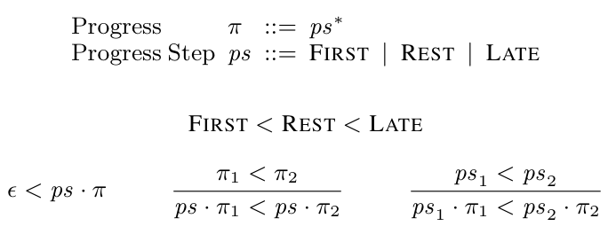

进度Progress

进度步骤Progress Step

图 5. 进度Figure 5. Progress

图 5 将我们的进度概念定义为进度步骤的序列。进度步骤 FIRST 和 REST 分别表示复合项的首部和其余部分。解析从左向右进行；如果解析器正在查看复合项的其余部分，那么首部必定已经成功解析。进度按字典序排序。步骤从左向右记录，例如，序列中的第二项写作 REST `·` FIRST；也就是说，先取完整项的其余部分，再取所得结果的首部。Figure 5 defines our notion of progress as sequences of progress steps. The progress steps FIRST and REST indicate the first and rest of a compound term, respectively. Parsing is performed left to right; if the parser is looking at the rest of a compound term, the first part must have been parsed successfully. Progress is ordered lexicographically. Steps are recorded left to right, so for example the second term in a sequence is written REST `·` FIRST; that is, take the rest of the full term and then the first part of that.

考虑以下错误的 `let` 项：Consider the following erroneous `let` term:

```
(let ([a 1] [2 b]) (* a b))
```

具名 `let` 子句在第二个子项处失败，其进度串为 REST `·` FIRST：The named-`let` clause fails at the second sub-term with the progress string REST `·` FIRST:

```
(let ([a 1] [2 b]) (* a b))
```

然而，普通 `let` 子句在第二个实参内部更深的位置失败，其进度为 REST `·` FIRST `·` REST `·` FIRST `·` FIRST：The normal-`let` clause, however, fails deeper within the second argument, at REST `·` FIRST `·` REST `·` FIRST `·` FIRST:

```
(let ([a 1] [2 b]) (* a b))
```

第二个序列表示的进度严格大于 REST `·` FIRST。因此，第二个失败被选中，宏会报告：在 `2` 的位置预期的是标识符。This second sequence denotes strictly more progress than REST `·` FIRST. Thus, the second failure is selected, and the macro reports that it expected an identifier in place of `2`.

匹配进度不仅仅度量项中的位置。考虑以下示例：Matching progress is not only a measure of position in a term. Consider the following example:

```
(let ([x 1] [x 2]) (+ x x))
```

两个子句对有问题的子项的判断一致。但这个示例显然更接近普通 `let` 的用法，而非具名 `let`。有问题的项符合 distinct-bindings 的结构，只是不满足附加条件。Both clauses agree on the faulty subterm. But this example is clearly closer to a use of normal-`let` rather than named-`let`. The faulty term matches the structure of *distinct-bindings*, just not the side condition.

从实用角度出发，我们将附加条件检查视为在遍历项之后发生，这与标注检查不同。名为 LATE 的进度步骤表示附加条件失败。因此，在上例中，具名 `let` 子句失败时的进度串为 REST`·`FIRST，而普通 `let` 子句失败时的进度为 REST `·` FIRST `·` LATE，后者比前者的进度更大。Pragmatically, we consider a check for side conditions—in contrast to an annotation check—to occur *after* traversal of the term. A progress step dubbed LATE signals the failure of a side condition. Thus, while the named-`let` clause fails with the progress string REST`·`FIRST in the example above, the normal-`let` clause fails with REST `·` FIRST `·` LATE, which is greater progress than the first.

有时多个备选项会在同一位置失败，例如：Sometimes multiple alternatives fail at the same place, e.g.,

```
> (let 5)
let: expected identifier or sequence of binding pairs in: 5
```

两个子句在这个项上取得的进度相同：REST `·` FIRST。因此，两个失败都会被选中，错误消息中会包含两种描述。Both clauses make the same amount of progress with this term: REST `·` FIRST. As a result, both failures are selected, and the error message includes both descriptions.

### 4.2 错误消息4.2 Error messages

除了进度，失败还包含一条说明错误性质的消息，以及发生失败的项。一条典型的错误消息如下：In addition to progress, a failure contains a message that indicates the nature of the error and the term where the failure occurred. A typical error message is

```
let: expected binding pair in: x
```

这条消息由宏所预期的内容（一个绑定对）和解析失败的具体项（`x`）组成。This message consists of the macro’s expectations (a binding pair) and the specific term where parsing failed (`x`).

语法错误应指出有问题的项，并简洁解释预期的内容。它不应复述宏的文档；相反，错误消息应便于定位相应文档，例如通过链接和引用。因此，`syntax-parse` 只使用有限种类的素材来生成消息。它会为字面量模式和数据模式自动合成消息；例如，模式 `5` 会产生消息“预期字面量 5”。作为特例，它还知道如何报告复合项包含过多子项的情况。除此之外，它使用的其他素材均由宏开发者提供：描述和附加条件消息。A syntax error should identify the faulty term and concisely explain what was expected. It should not recapitulate the macro’s documentation; rather, the error message should make locating the appropriate documentation easy, e.g., via links and references. Consequently, `syntax-parse` produces messages from a limited set of ingredients. It automatically synthesizes messages for literal and datum patterns; for example, the pattern `5` yields the message “expected the literal 5.” As a special case, it also knows how to report when a compound term has too many sub-terms. The only other ingredients it uses are provided by the macro developer: descriptions and side-condition messages.

特别地，`syntax-parse` 不会合成用于描述复合模式的消息。我们将这样的模式及其造成的失败称为“不可言述的”；我们的系统无法为它们生成解释。以下模式就是一个例子：In particular, `syntax-parse` does not synthesize messages to describe compound patterns. We call such patterns and the failures they cause “ineffable”; our system cannot generate explanations for them. An example is the following pattern:

```
(var:identifier rhs:expr)
```

如果将 `5` 这样的项与此模式匹配，它无法匹配该模式的复合结构。匹配过程不会进入标识符或表达式检查。一种可能的错误消息是“预期由一个标识符和一个表达式组成的复合项”。另一种是“预期 (identifier expr)”。实践中，宏编写者偶尔会编写这两种形式的错误消息。我们选择不自动生成这样的消息，原因有二：第一，它们难以很好地适用于大型或复杂的模式；第二，我们认为这类消息的方向有误。If a term such as `5` is matched against this pattern, it fails to match the compound structure of the pattern. The matching process does not reach the identifier or expression check. One possible error message is “expected a compound term consisting of an identifier and an expression.” Another is “expected (identifier expr).” In practice, macro writers occasionally write error messages of both forms. We have chosen not to generate such messages automatically for two reasons: first, they do not scale well to large or sophisticated patterns; and second, we consider such messages misguided.

当模式很简单时，例如上例，从模式生成消息是可行的。然而，对于嵌套更深的模式以及使用高级特性的模式，生成准确消息无异于直接显示模式本身。虽然在失败时显示模式有助于宏开发者调试，但这不是构建健壮语言抽象的好方法。错误报告应当基于文档中阐明的概念，而不是实现细节。Generating messages from patterns is feasible when the patterns are simple, such as the example above. For patterns with deeper nesting and patterns using advanced features, however, generating an accurate message is tantamount to simply displaying the pattern itself. While showing patterns in failures is a useful debugging aid for macro developers, it is a bad way to construct robust linguistic abstractions. *Error reporting should be based on documented* *concepts, not implementation details.*

当上述这样的复合模式失败时，系统会搜索该模式的上下文，并使用最近的外围描述来报告错误。考虑 `let` 的以下错误用法：When a compound pattern such as the one above fails, the pattern’s context is searched and the nearest enclosing description is used to report the error. Consider the following misuse of `let`:

```
(let (x 1) (add1 x))
```

第 4.1 节的错误选择算法确定，最具体的失败发生在尝试将 `x` 与模式 (var:identifier rhs:expr) 匹配时。以下是该失败的完整上下文：The error selection algorithm from section 4.1 determines that the most specific failure arose trying to match `x` against the pattern (*var:identifier rhs:expr*). Here is the full context of the failure:

- `•` 将 `x` 与 (var:identifier rhs:expr) 匹配时失败`•` matching `x` against (*var:identifier rhs:expr*) failed
- `•` 当时正在将 `x` 与 b:binding 匹配`•` while matching `x` against *b:binding*
- `•` 当时正在将 (`x 1`) 与 bs:distinct-bindings 匹配`•` while matching (`x 1`) against *bs:distinct-bindings*
- `•` 当时正在将 (`let` (`x 1`) (add1 x)) 与复合模式 (`let` bs:distinct-bindings body:expr) 匹配`•` while matching (`let` (`x 1`) (*add1 x*)) against the complex pattern (`let` *bs:distinct-bindings body:expr*)

第一帧和第四帧包含不可言述的模式。舍弃它们，并改述预期语法，便得到以下上下文：The first and fourth frames contain ineffable patterns. Discarding them and rephrasing the expected syntax gives us the following context:

- `•` 预期绑定对，实际给出 `x``•` expected binding pair, given `x`
- `•` 预期绑定对序列，实际给出 (`x 1`)`•` expected sequence of binding pairs, given (`x 1`)

由于第一帧最近，因此使用该帧的消息和项来构造错误消息“`let`: expected binding pair in: `x`”。The message and term of the first frame are used to formulate the error message “`let`: expected binding pair in: `x`” because it is the closest one.

## 5. 语法模式5. Syntax patterns

`syntax-parse` 的强大能力源于其表现力丰富的模式语言，它是对 MBE 语法模式的扩展。第 3 节和第 4 节已经介绍了我们的模式语言的一些特性。本节描述其他模式形式；根据我们的经验，这些形式使系统的表达能力达到制定实际语法规约所需的水平。The power of `syntax-parse` is due to its expressive pattern language, an extension of the syntax patterns of MBE. Sections 3 and 4 have introduced some features of our pattern language. This section describes additional pattern forms that, in our experience, increase the expressive power of our system to the level necessary for developing real syntax specifications.

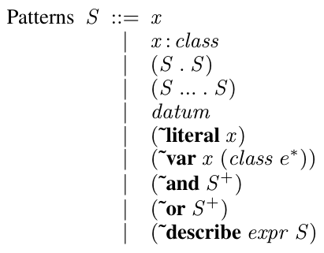

图 6. 单项模式Figure 6. Single-term patterns

### 5.1 单项模式5.1 Single-term patterns

图 6 描述了语法模式的语法，具体而言是单项模式，即规定单个项所构成集合的那类模式。前四种——模式变量、带标注的模式变量、对模式和省略号模式——已在第 3 节出现。数据模式也在那里以 () 的形式出现，用来终结复合模式。1 一般而言，数字、布尔值和字符串等数据都可以作为匹配其自身的模式。̃literal 模式形式2 识别与其所包含的标识符具有相同绑定的标识符；这Figure 6 describes the syntax of syntax patterns, specifically *single-term patterns*, the kind of pattern that specifies sets of single terms. The first four—pattern variables, annotated pattern variables, pair patterns, and ellipsis patterns—appear in section 3. So do datum patterns, in the form of (), which ends compound patterns.1 In general, data like numbers, booleans, and strings can be used as patterns that match themselves. The ̃literal pattern form2 recognizes identifiers that have the same binding as the enclosed identifier; this

1 记法 (a b) 是 (`a` . (`b` . ())) 的简写。2 所有模式关键字都以波浪号（̃）开头。1 The notation (*a b*) is shorthand for (`a` . (`b` . ())). 2 All pattern keywords start with a tilde ( ̃).

```
(define-syntax-class distinct-bindings
  #:description "sequence of binding pairs"
  (pattern (~var bs (bindings-excluding '()))
    #:with (var ...) (bs.var ...)
    #:with (rhs ...) (bs.rhs ...)))

;; seen is a list of identifiers
(define-syntax-class (bindings-excluding seen)
  (pattern ()
    #:with (var ...) '()
    #:with (rhs ...) '())
  (pattern ([(~var var0 (id-excluding seen)) rhs0]
            . (~var rest (bindings-excluding (cons #'var0 seen))))
    #:with (var ...) #'(var0 rest.var ...)
    #:with (rhs ...) #'(rhs0 rest.rhs ...)))

;; seen is a list of identifiers
(define-syntax-class (id-excluding seen)
  (pattern x:identifier
    #:fail-when (for/or ([id seen])
                  (bound-identifier=? #'x id))
    "duplicate variable name"))
```

图 7. 参数化语法类Figure 7. Parameterized syntax classes

是卫生宏系统中标识符相等性的标准概念 [Dybvig et al. 1993]。is the standard notion of identifier equality in hygienic macro systems [Dybvig et al. 1993].

̃var 模式将模式变量约束到某个语法类。冒号记法是无参数语法类的简写；例如，x:identifier 是 ( ̃var `x` (identifier)) 的简写。当语法类带有参数时，必须使用显式的 ̃var 记法。A ̃var pattern constrains a pattern variable to a syntax class. The colon notation is a shorthand for parameterless syntax classes; e.g., *x:identifier* is short for ( ̃var `x` (*identifier*)). When the syntax class takes parameters, the explicit ̃var notation is required.

语法类的参数可以用于其子表达式，包括描述及任何附加条件。例如，下面是一个识别小于某个上界的自然数字面量的语法类：A syntax class’s parameters may be used in its sub-expressions, including its description and any of its side conditions. For example, here is a syntax class that recognizes literal natural numbers less than some upper bound:

```
;; ex.: the pattern (~var n (nat< 10)) matches
;; any literal natural number less than 10
(define-syntax-class (nat< bound)
  #:description (format "natural number < ~s" bound)
  (pattern n:nat
    #:fail-when (not (< (syntax->datum #'n) bound))
    (format "got a number ~s or greater" bound)))
```

注意如何使用 format 过程，将上界同时插入描述和检查消息中。Notice how the upper bound is inserted into both the description and the check message using the *format* procedure.

我们可以使用参数化语法类，通过一个以已见到的标识符为参数的语法类，为 distinct-bindings 给出另一种定义。图 7 展示了这一定义及其辅助语法类 bindings-excluding 和 id-excluding。bindings-excluding 语法类接受由互不相同的绑定组成的序列，同时要求绑定的名称不出现在 seen 中。考虑 bindings-excluding 的第二个模式；var0 必须是不在 seen 中的标识符，而绑定到 var0 的标识符会被加入绑定序列剩余部分的标识符黑名单中。注意，var0 在传给 bindings-excluding 的实参中处于作用域内。由于模式从左向右匹配，模式变量的绑定也从左向右进行，遵循作用域由控制支配关系决定的原则 [Shivers 2005]。We can use parameterized syntax classes to give an alternative definition of *distinct-bindings*, via a syntax class parameterized over the identifiers that have already been seen. Figure 7 shows the alternative definition and the auxiliaries *bindings-excluding* and *id-excluding*. The pattern *bindings-excluding* syntax class accepts sequences of distinct bindings but also requires that the bound names not occur in *seen*. Consider *bindings-excluding*’s second pattern; *var0* must be an identifier not in *seen*, and the identifier bound to *var0* is added to the blacklisted identifiers for the rest of the binding sequence. Note that *var0* is in scope in the argument to *bindings-excluding*. Since patterns are matched left to right, pattern variable binding also runs left to right, following the principle of scope being determined by control dominance [Shivers 2005].

虽然接受的项相同，但 distinct-bindings 的这一替代定义与第 3.2 节中的定义在错误报告方式上有所不同。第一种定义先验证绑定对的结构，再检查名称是否重复。第二种定义则在同一趟处理中检查结构和重复项。因此，对于下面的项，两者会报告不同的错误：While it *accepts* the same terms, this alternative definition of *distinct-bindings* reports errors differently from the one in section 3.2. The first definition verifies the structure of the binding pairs first, then checks for a duplicate name. The second checks the structure and checks duplicates in the same pass. They thus report different errors for the following term:

```
(let ([a 1] [a 2] [x y z]) a)
```

在这种情况下，宏编写者必须决定最合适的验证顺序。In such cases, the macro writer must decide the most suitable order of validation.

̃and 模式形式提供了一种以多种方式分析同一个项的方法。在 ̃and 模式内部，匹配与绑定按从左到右的顺序进行，因此后面的子模式可以依赖前面的子模式。The ̃and pattern form provides a way of analyzing a term multiple ways. Matching order and binding go left to right within an ̃and pattern, so later sub-patterns can rely on earlier ones.

只要任一子模式匹配，̃or 形式就匹配。许多模式匹配系统即使支持析取，也要求各析取分支绑定相同的模式变量；与之不同，̃or 模式更加灵活。̃or 模式绑定其各析取分支的属性的并集，而未出现在匹配分支中的属性会被标记为“缺失”。The ̃or form matches if any of its sub-patterns match. Unlike in many pattern matching systems, where disjunction, if it is supported at all, requires that the disjuncts bind the same pattern variables, ̃or patterns are more flexible. An ̃or pattern binds the *union* of its disjuncts’ attributes, and those attributes that do not occur in the matching disjunct are marked “absent.”

在语法模板中使用缺失的属性是不合法的，因此 `syntax-parse` 提供了 attribute 形式，用于访问属性的值；对于缺失的属性，它返回假。借助 attribute，程序员可以检查在模板中使用某个属性是否安全。下面是一个为 class 宏解析字段声明的辅助函数，其中字段声明包含一个名称，或者分别指定的内部名称和外部名称：It is illegal to use an absent attribute in a syntax template, so `syntax-parse` provides the *attribute* form, which accesses the value of the attribute, returning *false* for absent attributes. Using *attribute*, a programmer can check whether it is safe to use an attribute in a template. Here is an auxiliary function for parsing field declarations for a class macro, where a field declaration contains either a single name or distinct internal and external names:

```
(define (parse-field-declaration stx)
  (syntax-parse stx
    [(~or field:identifier [internal:identifier field:identifier])
     (make-field (if (attribute internal) #'internal #'field)
                 #'field)]))
```

̃or 模式的某些用法更适合表示为语法类，其中一个重要原因是，语法类可以使用 `#:with` 子句来绑定缺失的属性：Some uses of ̃or patterns are better expressed as syntax classes, not least because a syntax class can use a `#:with` clause to bind missing attributes:

```
(define-syntax-class field-declaration
  (pattern field:id
    #:with internal #'field)
  (pattern [internal:id field:id]))
```

最后一种模式形式 ̃describe 将一个新描述 `d` 压入其子模式的匹配上下文。因此，如果发生失败，且没有其他描述更接近错误源，就使用描述 `d` 来解释该失败。The final pattern form, ̃describe, pushes a new description `d` onto the matching context of its sub-pattern. Hence, if a failure occurs and if there is no other description closer to the source of the error, the description `d` is used to explain the failure.

附加到语法类上的描述与通过 ̃describe 给出的描述并无区别。回顾第 3.2 节中的 binding 和 distinctbindings 语法类定义；binding 语法类可以如下内联到 distinct-bindings 中：There is no difference between a description attached to a syntax class and one given via ̃describe. Recall the *binding* and *distinctbindings* syntax class definitions from section 3.2; the *binding* syntax class could be inlined into *distinct-bindings* as follows:

```
(define-syntax-class distinct-bindings
  #:description "sequence of distinct binding pairs"
  (pattern ((~describe "binding pair"
              [var:identifier rhs:expr]) ...)
    #:fail-when ——))
```

事实上，可以使用 ̃describe 和动作模式，将 distinct-bindings 内联到 `let` 宏本身中。In fact, *distinct-bindings* could be inlined into the `let` macro itself using ̃describe and action patterns.

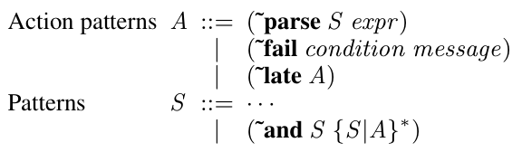

图 8. 动作模式Figure 8. Action patterns

### 5.2 动作模式5.2 Action patterns

图 8 中的动作模式并不描述语法；相反，它们在不消耗输入的情况下影响解析过程。̃parse 形式允许程序员将匹配从当前输入转向计算得到的项；̃fail 提供了一种显式引发匹配失败的方法；而 ̃late 则影响失败的排序。The action patterns of figure 8 do not describe syntax; instead, they affect the parsing process without consuming input. The ̃parse form allows the programmer to divert matching from the current input to a computed term; ̃fail provides a way of explicitly causing a match failure; and ̃late affects the ordering of failures.

̃parse 形式求值其子表达式，并将结果与给定模式匹配。̃parse 形式的一种用途是在 ̃or 模式中绑定默认值，从而避免稍后显式检查属性。回顾 parse-field-declaration。在这里，两个分支都绑定了 `internal`，从而简化了结果模板：The ̃parse form evaluates its sub-expression and matches it against the given pattern. One use for the ̃parse form is to bind default values within an ̃or pattern, avoiding the need for explicit *attribute* checks later. Recall *parse-field-declaration*. Here `internal` is bound in both alternatives, simplifying the result template:

```
(define (parse-field-declaration stx)
  (syntax-parse stx
    [(~or (~and field:identifier (~parse internal #'field))
          [internal:identifier field:identifier])
     (make-field #'internal #'field)]))
```

这个例子还展示了如何使用 ̃and 将动作模式安排在单项模式之后。由于 ̃and 会将其各子模式中绑定的属性传递给后续子模式，因此可以使用 ̃and 先解析一个项，再根据该项的内容执行动作。This example also shows the use of ̃and to sequence an action pattern after a single-term pattern. Since ̃and propagates attributes bound in each of its sub-patterns to subsequent sub-patterns, ̃and can be used to parse a term and then perform actions depending on the contents of the term.

̃fail 模式允许程序员执行附加约束检查。此外，如果条件求值为一个语法值，该值就会作为导致错误的具体项添加到失败中。The ̃fail patterns allow programmers to perform side-constraint checks. Additionally, if the condition evaluates to a syntax value, it is added to the failure as the specific term that caused the error.

默认情况下，̃fail 执行早期检查。例如，identifier 语法类将其测试作为早期检查来执行：By default, ̃fail performs early checks. For example, the *identifier* syntax class performs its test as an early check:

```
(define-syntax-class identifier
  (pattern (~and x (~fail (not (identifier? #'x)) no-msg))))
```

̃late 形式将其中包含的检查转换为晚期检查。事实上，distinct-bindings 中使用的 `#:fail-when` 关键字选项只是 ̃late 与 ̃fail 组合的简写：The ̃late form turns enclosed checks into late checks. In fact, the `#:fail-when` keyword option used in *distinct-bindings* is just shorthand for a combination of ̃late and ̃fail:

```
(define-syntax-class distinct-bindings
  #:description "sequence of distinct bindings"
  (pattern (~and (b:binding ...)
                 (~late (~fail (check-duplicate #'(b.var ...))
                               "duplicate variable name")))))
```

### 5.3 头部模式5.3 Head patterns

第 5.1 和 5.2 节中的模式不足以解析图 3 中的 `define-struct` 这类宏。`define-struct` 的某些语法元素由多个连续的项组成，但单项模式只描述单个项，而动作模式根本不描述项。例如，一次 super 选项的出现由两个相邻的项组成：关键字 `#:super`，后接一个表达式，例如，The patterns of Sections 5.1 and 5.2 do not provide the power needed to parse macros like `define-struct` from figure 3. There are elements of `define-struct`’s syntax that comprise multiple consecutive terms, but single-term patterns describe only single terms, and action patterns do not describe terms at all. An occurrence of the super option, for example, consists of two adjacent terms: the keyword `#:super` followed by an expression, e.g.,

```
(define-struct point (x y) #:super geometry #:mutable)
```

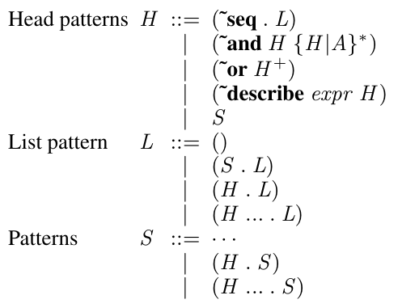

图 9. 头部模式Figure 9. Head patterns

我们的解决方案是引入图 9 中的头部模式，用于描述项的序列。主要的头部模式构造器是 ̃seq，其后跟一个正规列表模式 (`L`)。例如，( ̃seq x:identifier . . . y:expr) 匹配任意多个标识符后接一个表达式的序列。与之对比，模式 (x:identifier . . . y:expr) 则匹配 `a` 个复合 `term`，其中包含一个标识符序列，后接一个表达式。Our solution is to introduce the *head patterns* of figure 9, which describe sequences of terms. The primary head pattern constructor is ̃seq, which is followed by a proper list pattern (`L`). For example, ( ̃seq *x:identifier* . . . *y:expr*) matches a sequence of any number of identifiers followed by one expression. Contrast that pattern with (*x:identifier* . . . *y:expr*), which matches `a` *single compound* `term` containing a sequence of identifiers followed by an expression.

头部模式可以与普通的单项模式组合，构成一个单项模式。组合后的模式通过尝试将一个项拆分为匹配头部模式的项序列前缀，以及匹配尾部的后缀项，来匹配该项。如果前缀可以为空，该项就不必是复合项。例如，模式 (( ̃seq x y z) w:identifier ...) 能够匹配项 (`1 2 3` `a` `b`)，因为该项可以拆分为包含三个项 `1 2 3` 的前缀（匹配 ( ̃seq `x` `y` `z`)）以及后缀 (`a` `b`)（匹配 (w:identifier . . . )）。当然，(( ̃seq x y z) w:identifier ... ) 等价于 (x y z w:identifier ...)。̃seq 模式主要在与其他模式形式（如 ̃and 和 ̃or）组合时有用，例如用于带有可选关键字参数的宏：A head pattern may be combined with a normal single-term pattern to form a single-term pattern. The combined pattern matches a term by attempting to split it into a prefix sequence of terms that matches the head pattern and a suffix term that matches the tail. The term need not be a compound term if the prefix can be empty. For example, the pattern (( ̃seq *x y z*) *w:identifier* ...) matches the term (`1 2 3` `a` `b`) because the term can be split into the prefix of three terms `1 2 3` matching ( ̃seq `x` `y` `z`) and the suffix (`a` `b`) matching (*w:identifier* . . . ). Of course, (( ̃seq *x y z*) *w:identifier* ... ) is equivalent to (*x y z w:identifier* ...). The ̃seq pattern is useful primarily when combined with other pattern forms, such as ̃and and ̃or, as in macros with optional keyword arguments:

```
(define-syntax (test-case stx)
  (syntax-parse stx
    [(test-case (~or (~seq #:around proc) (~seq)) e:expr)
     —— (attribute proc) ——]))
```

当然，头部模式本质上并不依赖关键字。我们可以用下面的模式来描述 `let` 的语法，同时兼容普通 `let` 和具名 `let` 语法：Head patterns are not intrinsically tied to keywords, of course. We could describe the syntax of `let`, accommodating both normal-`let` and named-`let` syntax, with the following pattern:

```
(let (~or (~seq loop:identifier) (~seq)) bs:distinct-bindings
  body:expr)
```

拼接语法类封装头部模式。它的每个变体都是一个头部模式 (`H` )，最常见的是 ̃seq 模式，不过也可以是其他类型的头部模式。可选的 `#:around` 关键字参数可以如下提取：Splicing syntax classes encapsulate head patterns. Each of its variants is a head pattern (`H` ), most often a ̃seq pattern, although other kinds of head pattern are possible. The optional `#:around` keyword argument could be extracted thus:

```
(define-splicing-syntax-class optional-around
  (pattern (~seq #:around proc))
  (pattern (~seq)
    #:with proc #'(λ (p) (p))))
```

用拼接语法类标注的模式变量可以表示多个项。在这个例子中，ka 匹配两个项：A pattern variable annotated with a splicing syntax class can represent multiple terms. In this example, *ka* matches two terms:

```
(define-syntax (test-case stx)
  (syntax-parse stx
    [(test-case ka:optional-around e) —— #'ka.proc ——]))
(test-case #:around call-with-connection ——)
```

头部模式也可以出现在省略号前面。在这些情况下，还有几种额外的变体可用，使宏编写者能够支持以任意顺序出现的多个可选参数。Head patterns can also occur in front of ellipses. In those cases, a few additional variants are available that enable macro writers to support multiple optional arguments occurring in any order.

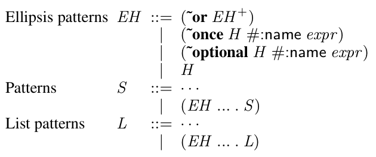

图 10. 省略号头部模式Figure 10. Ellipsis-head patterns

### 5.4 省略号头部模式5.4 Ellipsis-head patterns

图 5.4 中给出的省略号头部模式，是指定 `define-struct` 的关键字选项这类语法所需的最后一个要素。省略号头部模式可以有多个通过 ̃or 组合的分支；每个分支都是头部模式。它指定Ellipsis-head patterns—specified in figure 5.4 are the final ingredient necessary to specify syntax like the keyword options of `define-struct`. An ellipsis-head pattern may have multiple alternatives combined with ̃or; each alternative is a head pattern. It specifies

```
(define-struct name:identifier (field:identifier ...)
  (~or (~optional (~seq #:mutable) #:name "mutable clause")
       (~optional (~seq #:super super-expr) #:name "super clause")
       (~optional (~or (~seq #:inspector inspector-expr)
                       (~seq #:transparent))
                  #:name "inspector or transparent clause")
       (~seq #:property pkey:expr pval:expr))
  ...)))
```

图 11. 用于 define-struct 的 syntax-parse 模式Figure 11. syntax-parse pattern for define-struct

由若干个分支实例连接而成的序列。一个分支可以用两种重复约束形式之一来标注，即 ̃optional 和 ̃once，以限制该分支在序列中可以出现的次数。sequences consisting of some number of instances of the alternatives joined together. An alternative may be annotated with one of two *repetition constraint* forms, ̃optional and ̃once, that restrict the number of times that alternative may appear in the sequence.

当 ̃or 模式紧接在省略号之前时，其含义略有变化。不再为每个未选中的分支累积“缺失”值，而是只有选中的分支才累积属性值。因此，当项 (`1` `a 2` `b` `c`) 与模式 (( ̃or x:identifier y:number) . . . ) 匹配时，`x` 匹配 (a b c)，而 `y` 匹配 (`1 2`)。The meaning of an ̃or-pattern changes slightly when it occurs immediately before ellipses. Instead of “absent” values accruing for every alternative that is not chosen, only the chosen alternative accrues attribute values. Consequently, when the term (`1` `a 2` `b` `c`) is matched against the pattern (( ̃or *x:identifier y:number*) . . . ), `x` matches (*a b c*) and `y` matches (`1 2`).

对省略号和头部模式的这些扩展，提供了足以指定 `define-struct` 语法的能力。图 11 展示了完整模式。字段之后是可以任意排序的关键字选项。关键字及其参数通过 ̃seq 模式组合在一起。许多选项最多只能出现一次，因此用 ̃optional 模式将其包裹。例外是 `#:property` 选项，它可以出现任意多次。`#:inspector` 和 `#:transparent` 选项互斥，因此被组合在同一个 ̃optional 析取分支之下。These extensions to ellipses and head patterns provide enough power to specify `define-struct`’s syntax. Figure 11 shows the complete pattern. After the fields come the keyword options, in any order. Keywords and their arguments are grouped together with ̃seq patterns. Many of the options can occur at most once, so they are wrapped with ̃optional patterns. The exception is the `#:property` option, which can occur any number of times. The `#:inspector` and `#:transparent` options are mutually exclusive, so they are grouped together under one ̃optional disjunct.

## 6. 语义6. Semantics

`syntax-parse` 的匹配算法基于两条原则：The `syntax-parse` matching algorithm is based on two principles:

- `•` 根据进度从所有失败中选择错误。`•` Errors are selected from all failures based on progress.
- `•` 使用显式提供的描述来描述错误。`•` Errors are described using explicitly-provided descriptions.

本节给出 `syntax-parse` 中模式匹配的语义，并解释它如何实现这两条原则。错误选择算法表示为一个回溯单子，其中的失败概念包含匹配进度。错误描述原则则由语义函数实现，这些函数将错误描述作为继承属性进行传播。This section presents the semantics of pattern matching in `syntax-parse` and explains how it implements the two principles. The error selection algorithm is represented by a backtracking monad with a notion of failure that incorporates matching progress. The error description principle is implemented by the semantic functions, which propagate error descriptions as an inherited attribute.

### 6.1 跟踪失败6.1 Tracking failure

我们用一个“单淘汰”单子来建模带有失败信息的回溯，它是众所周知的回溯单子的一个变体 [Hughes 1995]。单淘汰 (`SE`) 序列由一个有限的成功列表 (`ai`) 组成，并以至多一个失败 (`φ`) 结束：We model backtracking with failure information with a “single-elimination” monad, a variant of well-known backtracking monads [Hughes 1995]. A single-elimination (`SE`) sequence consists of a finite list of successes (`ai`) terminated by at most one failure (`φ`):

该单子以成功元素的类型为参数；见下文。成功序列可以为空。为简明起见，我们总是包含失败，并用 `•` 表示“无失败”。The monad is parameterized by the type of success elements; see below. The sequences of successes may be empty. For simplicity we always include the failure and use `•` to represent “no failure.”

这个单子的重要之处在于对失败的处理，这建模了我们宏系统的错误选择算法。一个失败（`•` 除外）由一个进度 (`π`) 和一组原因 (`l`) 组成。每个原因由一个项和一条消息组成。组合序列时，其失败会被合并：(1) 选择进度最大（见图 5）的失败；(2) 如果它们的进度相同，则合并其消息集。单位元是 `•`；它被视为比任何其他失败的进度都小。`Failure` 是一个以 `•` 为最小元的有界并半格。The important aspect of this monad is its handling of failures, which models our macro system’s error selection algorithm. A failure (other than `•`) consists of a progress (`π`) together with a set of reasons (`l`). Each reason consists of a term and a message. When sequences are combined, their failures are joined: (1) the failure with the greatest progress (see figure 5) is selected; (2) if they have the same progress, their message sets are combined. The identity element is `•`; it is considered to have less progress than any other failure. `Failure` is a bounded join-semilattice with least element `•`.

图 12 定义了该单子的操作，包括 `unit`、绑定（记为 `⋆`）和析取（记为 `ˆ` ）。`unit` 操作创建一个Figure 12 defines the monad’s operations, including `unit`, bind (written `⋆`), and disjoin (written `ˆ` ). The `unit` operation creates a

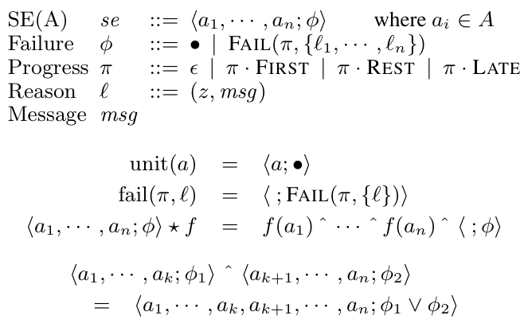

其中 ai ∈ Awhere ai ∈ A

图 12. 单淘汰序列及其操作Figure 12. Single-elimination sequences and operations

包含一个成功且不包含失败的序列。析取 ( `ˆ` ) 连接成功，并对失败取并 (`∨`)；绑定 (`⋆`) 将一个函数应用于序列中的所有成功，并将产生的序列与原来的失败组合。除了处理失败的方式外，这个单子与标准的列表单子相似。sequence of one success and no failure. Disjoin ( `ˆ` ) concatenates successes and joins (`∨`) the failures, and bind (`⋆`) applies a function to all successes in a sequence and combines the resulting sequences with the original failure. This monad is similar to the standard list monad except for the way it handles failures.

人们或许会期待采用更简单的模型，即成功列表或者一个失败。毕竟，如果一个模式成功，回溯通常只会由进度更大的失败触发，这会使前一个模式中的任何失败都变得无关紧要。然而，情况并非总是如此。此外，与看似更简单的模型相比，我们的选择有两个优点。首先，纯粹按进度对失败排序很有说服力，也易于程序员理解。其次，这个单子恰好对应于一种双续延实现 [Wand and Vaillancourt 2004]。One might expect to use the simpler model of a list of successes *or* a failure. After all, if a pattern succeeds, backtracking typically occurs only when triggered by a failure of greater progress, which would make any failure in the prior pattern irrelevant. This is not always the case, however. Furthermore, our choice has two advantages over the seemingly simpler model. First, ranking failures purely by progress is compelling and easy for programmers to understand. Second, this monad corresponds neatly to a two-continuation implementation [Wand and Vaillancourt 2004].

### 6.2 域与签名6.2 Domains and signatures

我们在模式语言的核心版本上解释模式匹配。带标注模式变量的冒号简写被脱糖为 ̃var 形式。同样，所有数据模式都表示为显式的 ̃datum 模式。所有 ̃and 和 ̃or 模式都被转换为恰好包含两个子模式；̃and 模式必须左结合，以便原始 ̃and 模式中的任何动作模式都作为脱糖后的 ̃and 模式的第二个子模式出现。核心 ̃or 模式的各析取分支都绑定相同的属性；必要时通过 ̃and 和 ̃parse 添加额外绑定，以显式表示“缺失”的属性。We explain pattern matching on a core version of the pattern language. The colon shorthand for annotated pattern variables is desugared into the ̃var form. Similarly, all datum patterns are given as explicit ̃datum patterns. All ̃and and ̃or patterns are converted to have exactly two sub-patterns; ̃and patterns must be left-associated so that any action patterns in the original ̃and pattern occur as second sub-patterns of the desugared ̃and patterns. The disjuncts of core ̃or patterns all bind the same attributes; additional bindings via ̃and and ̃parse are added as necessary to make “absent” attributes explicit.

我们将重复约束形式 ̃optional 和 ̃once 推广为 ̃between 形式。无约束的省略号头部模式被建模为一个 ̃between 模式，其中 `N`min `= 0`，`N`max `= ∞`。每个重复析取分支都有一个用于跟踪重复次数的独立标签 (`R`)，以及两个消息表达式，一个报告重复次数过少，另一个报告重复次数过多。我们省略了属性的省略号嵌套深度；它是一种静态性质，因此容易单独计算。We generalize the repetition constraint forms ̃optional and ̃once to a ̃between form. An unconstrained ellipsis head pattern is modeled as a ̃between pattern with `N`*min* `= 0` and `N`*max* `= ∞`. Each repetition disjunct has a distinct label (`R`) used to track repetitions and two message expressions, one to report too few repetitions and one for too many. We omit the ellipsis nesting depth of attributes; it is a static property and as such easy to compute separately.

语法类接受一个参数，对语法类的引用也相应更新。语法类的各个变体合并成一个 ̃or 模式，再用一个包含该语法类描述的 ̃describe 模式包裹。Syntax classes take a single parameter and references to syntax classes are updated accordingly. The syntax class’s variants are combined into a single ̃or pattern, which is wrapped with a ̃describe pattern holding the syntax class’s description.

最后，我们假定存在一个用于求值表达式的 `eval` 函数。求值环境是一个替换，其中包含模式匹配过程中此前遇到的属性的映射。为简明起见，我们不对程序上下文所对应的环境进行建模。添加它很容易，但颇为繁琐。Finally, we assume an `eval` function for evaluating expressions. The environment of evaluation is a substitution with mappings for attributes encountered previously in the pattern matching process. For simplicity, we do not model the environment corresponding to the program context. It would be easy but tedious to add.

图 13 定义了语义中使用的其他域和操作，以及指称函数的签名。项由原子和项的“点对”组成。解析成功用一个将名称映射到项的替换 `σ` 表示。替换通过 `⊔` 运算符组合，生成一个替换，其属性绑定为两个参数的属性绑定的并集。我们Figure 13 defines the additional domains and operations used by the semantics as well as the signatures of the denotation functions. Terms consist of atoms and “dotted pairs” of terms. Parsing success is represented by a substitution `σ` mapping names to terms. Substitutions are combined by the `⊔` operator, which produces a substitution with the union of the two arguments’ attribute bindings. We

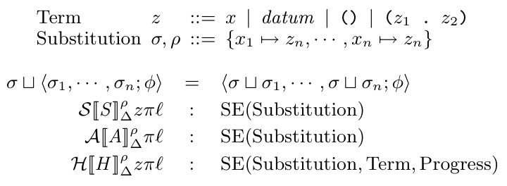

项Term

替换Substitution

图 13. 模式语义的域、操作与签名Figure 13. Domains, operations, signatures for pattern semantics

重载了组合运算符的记号；当右侧是一个 SE 序列时，它表示将左侧的替换与序列中的每个替换组合。overload the combination operator notation; when the right-hand side is a SE-sequence, it indicates that the left-hand substitution is combined with every substitution in the sequence.

模式指称函数以一个语法定义集 `∆` 和一个来自已匹配模式的替换 `ρ` 为参数。除相应的模式外，指称函数至多还接受三个参数：待解析的项 (`z`)、进度字符串 (`π`) 和失败原因 (`l`)。随着匹配算法深入该项，项参数和进度参数会发生变化。不过，动作模式不需要项参数。原因参数表示最近的外层描述；当匹配进入 ̃describe 形式时，它会发生变化。The pattern denotation functions are parameterized over a set of syntax definitions `∆` and a substitution `ρ` from patterns already matched. In addition to the appropriate patterns, the denotation functions take up to three additional arguments: a term (`z`) to parse, a progress string (`π`), and a failure reason (`l`). The term and progress arguments change as the matching algorithm descends into the term. The term argument is not needed, however, for action patterns. The reason argument represents the closest enclosing description; it changes when matching passes into a ̃describe form.

每个模式指称函数都返回一个表示成功与失败的 `SE` 序列。`S` 和 `A` 函数返回的序列以替换为成功元素。`H` 函数还包含项和进度字符串，用于指示从何处恢复匹配。Each of the pattern denotation function returns a `SE`-sequence representing successes and failure. The `S` and `A` functions return sequences whose success elements are substitutions. The `H` function additionally includes terms and progress strings, which indicate where to resume matching.

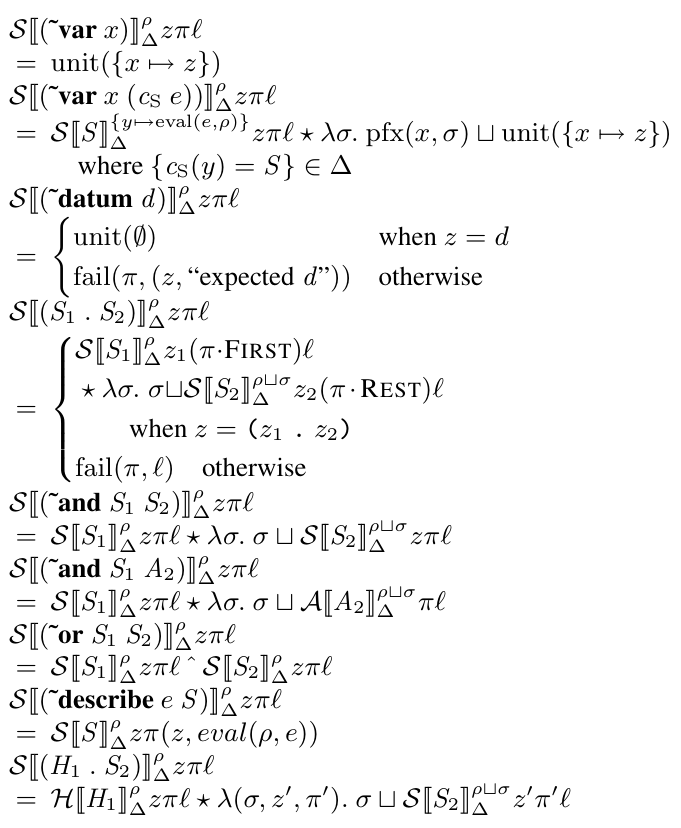

当 z = d 时when z = d

否则otherwise

当 z = (z1 . z2) 时when z = (z1 . z2)

图 14. S 模式的语义Figure 14. Semantics of S-patterns

### 6.3 含义6.3 Meaning

`syntax-parse` 表达式具有以下形式：A `syntax-parse` expression has the following form:

```
(syntax-parse stx [S1 rhs1] ... [Sn rhsn])
```

`syntax-parse` 表达式的含义通过以下指称定义：The meaning of the `syntax-parse` expression is defined via the following denotation:

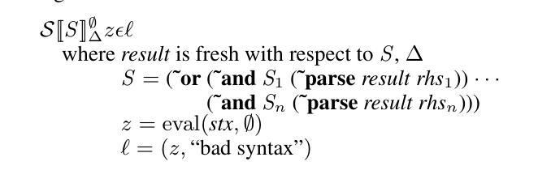

其中 result 相对于 S、Δ 是新鲜的where result is fresh with respect to S, Δ

如果序列中至少包含一个替换，`syntax-parse` 表达式的结果就是序列中第一个替换的 result 属性。否则，`syntax-parse` 表达式失败，其错误消息从 `SE` 序列的失败中导出。If the sequence contains at least one substitution, the result of the `syntax-parse` expression is the *result* attribute of the first substitution in the sequence. Otherwise, the `syntax-parse` expression fails with an error message derived from the `SE`-sequence’s failure.

图 14 展示了单项模式的指称。变量模式总能匹配，并生成一个将模式变量映射到输入项的替换。类模式根据语法类环境 `∆` 中记录的模式进行匹配。产生的各替换的属性都加上模式变量作为前缀 (`pfx`)，并添加模式变量本身的绑定。Figure 14 shows the denotations of single-term patterns. A variable pattern always matches, and it produces a substitution mapping the pattern variable to the input term. A class pattern matches according to the pattern recorded in the syntax class environment `∆`. The resulting substitutions’ attributes are prefixed (`pfx`) with the pattern variable, and the pattern variable binding itself is added.

当 ̃datum 模式失败时，它会根据预期的数据合成一条错误消息。其他模式变体使用继承的错误原因 (`l`)，它表示包围该模式的最近一层描述。也就是说，它表示匹配上下文中最近的“可解释”帧。When a ̃datum pattern fails, it synthesizes an error message based on the expected datum. The other pattern variants use the inherited error reason (`l`), which represents the closest enclosing description around the pattern. That is, it represents the nearest “explainable” frame in the matching context.

点对模式、头部模式和 ̃and 模式将其第一个子模式的成功替换传递给第二个子模式。这使模式中的表达式能够引用由先前模式绑定的属性。除每个成功替换外，头部模式还生成一个项和一个进度字符串；该项和进度指示从何处恢复匹配。The pair, head, and ̃and patterns propagate the success sub-stitutions from their first sub-patterns to their second sub-patterns. This allows expressions within patterns to refer to attributes bound by previous patterns. Head patterns also produce a term and progress string in addition to each success substitution; the term and progress indicate where to resume matching.

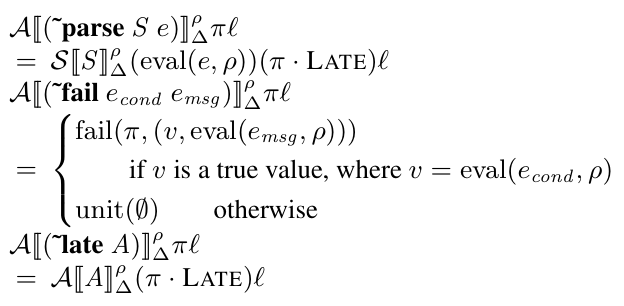

如果 v 为真值，其中 v = eval(econd, ρ)if v is a true value, where v = eval(econd, ρ)

否则otherwise

图 15. A 模式的语义Figure 15. Semantics of A-patterns

与其他类型的模式不同，动作模式不依赖于正在匹配的项。不过，它们和单项模式一样会生成记录。图 15 展示了动作模式的指称。̃parse 模式将其子表达式求值为一个项，并将该项与子模式匹配。̃fail 模式在先前属性的上下文中求值其条件表达式。根据结果，它要么以空记录成功，要么以关联的标签失败。̃late 形式扩展进度字符串，将其中包含的模式标记为晚期检查。Action patterns, unlike other kinds of patterns, do not depend on the term being matched. Like single-term patterns, however, they produce records. Figure 15 displays the denotations of action patterns. The ̃parse pattern evaluates its sub-expression to a term and matches that term against the sub-pattern. The ̃fail pattern evaluates its condition expression in the context of the previous attributes. Depending on the result, it either succeeds with an empty record or fails with the associated label. The ̃late form extends the progress string, marking the enclosed pattern as a late check.

如果嵌入的列表模式能够匹配由一组项组成的复合项，那么 ̃seq 模式就能匹配该项序列。我们没有复制并修改单项模式的指称函数来处理列表模式，而是复用 `S`，并添加一种新的单项模式变体 `(` ̃end-of-head`)`，将额外信息巧妙地放入替换中。对于头部 ̃and 模式，我们执行相反的转换；在第一个合取分支匹配一个项序列之后，我们将该序列转换为一个项 (`take`)。我们将第二个合取分支从头部模式转换为单项模式，并用它来匹配这个新项。A ̃seq pattern matches a sequence of terms if the embedded list pattern would match the compound term consisting of those terms. Rather than duplicating and modifying the denotation function for single-term patterns to work with list patterns, we reuse `S` and add a new variant of single-term pattern, `(` ̃end-of-head`)`, that sneaks the additional information into the substitution. For head ̃and patterns, we perform the opposite transformation; after the first conjunct matches a sequence of terms, we convert that sequence into a term (`take`). We convert the second conjunct from a head pattern to a single-term pattern and use it to match the new term.

我们省略了省略号模式的语义。它与头部模式的语义相似，但省略号头部模式还会We omit the semantics of ellipsis patterns. It is similar to the semantics of head patterns, but an ellipsis-head pattern additionally

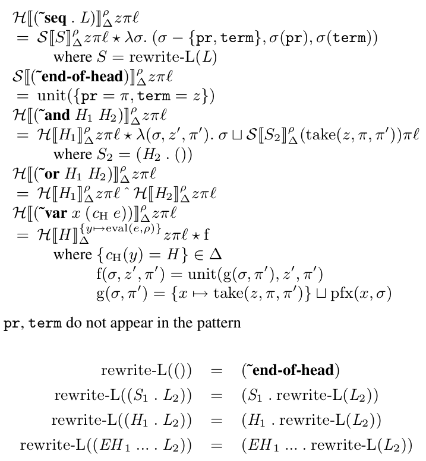

pr、term 不出现在模式中pr, term do not appear in the pattern

图 16. H 模式的语义Figure 16. Semantics of H-patterns

产生一个重复环境，将 ̃between 形式映射到它目前在序列中已出现的次数。当匹配进行到尾部时，会检查 ̃between 形式的下界；在头部模式的每次迭代中，都会检查其上界。yields a repetition environment mapping a ̃between form to the number of times it has occurred in the sequence so far. A ̃between form’s lower bound is checked when matching proceeds to the tail; its upper bound is checked on every iteration of the head pattern.

### 6.4 实现6.4 Implementation

`syntax-parse` 的实现采用回溯单子的双续延表示。在可能的情况下，成功续延表示为表达式，使替换表示在 Racket 的环境中，而非表示为数据结构。因此，这段代码类似于编译模式匹配的回溯自动机方法。我们尚未尝试将已知的模式匹配优化加入实现，但计划这样做。必须调整这些优化，以适应进度跟踪。例如，如果某个子句可能以比退出子句更大的进度失败，那么退出优化 [Fessant and Maranget 2001] 就不能仅因它不可能成功而将其跳过。The implementation of `syntax-parse` uses a two-continuation representation of the backtracking monad. The success continuation is represented as an expression where possible, so that substitutions are represented in Racket’s environment rather than as a data structure. Thus, the code is similar to the backtracking-automaton method of compiling pattern matching. We have not yet attempted to add known pattern-matching optimizations to our implementation but plan on doing so. Optimizations must be adapted to accommodate progress tracking. For example, exit optimization [Fessant and Maranget 2001] may not skip a clause that cannot succeed if the clause may fail with greater progress than the exiting clause.

## 7. 案例研究7. Case studies

Racket 纳入 `syntax-parse` 已有一年。用 `syntax-parse` 重新编写现有宏，可以将解析代码量缩减数倍，而不降低错误报告的质量。用户证实，`syntax-parse` 使编写复杂语法的宏变得容易。不过，主要益处在于提高了清晰性和健壮性。Racket has included `syntax-parse` for one year. Reformulating existing macros with `syntax-parse` can cut parsing code by several factors without loss in quality in error reporting. Users confirm that `syntax-parse` makes it easy to write macros for complex syntax. The primary benefit, however, is increased clarity and robustness.

本节给出两项案例研究，展示 `syntax-parse` 的应用。这两项案例从一系列大量案例中选出，覆盖了健壮性的两端；第一个案例最初几乎不做错误检查，而第二个案例则进行全面的错误检查。每项案例研究都先陈述用途，随后分析行为差异，并比较两份代码。This section presents two case studies illustrating applications of `syntax-parse`. The case studies are chosen from a large series to span the spectrum of robustness; the first case study initially performed almost no error checking, whereas the second case study checked errors aggressively. Each case study starts with a purpose statement, followed by an analysis of the difference in behavior and a comparison of the two pieces of code.

### 7.1 案例：loop7.1 Case: loop

`loop` 宏 [Shivers 2005] 允许程序员通过循环子句表达各种迭代构造。`loop` 宏是一个理想的案例研究对象，因为现有实现几乎不做错误检查，而且其作者作出了如下论断：The `loop` macro [Shivers 2005] allows programmers to express a wide range of iteration constructs via *loop clauses*. The `loop` macro is an ideal case study because the existing implementation performs almost no error-checking, and its author makes the following claim:

在健壮的工业级软件系统中，错误处理代码占据代码行数的大部分，这是常见的情况；loop 软件包也不例外。添加代码以提供细致的语法检查和清晰的错误消息，是一项繁琐但直接的实现工作。It is frequently the case with robust, industrial-strength software systems for error-handling code to dominate the line counts; the loop package is no different. Adding the code to provide careful syntax checking and clear error messages is tedious but straightforward implementation work.

> Olin Shivers，2005 年Olin Shivers, 2005

> 换句话说，预计为 `loop` 宏添加错误检查会使代码量翻倍。使用 `syntax-parse`，我们可以做得更好。In other words, adding error-checking to the `loop` macro is expected to *double* the size of the code. Using `syntax-parse` we can do better.

> 原始的 `loop` 宏很少做错误检查；在三十二个导出的宏中，只有三处语法验证检查，以及少量内部健全性检查。导出的宏包括 `loop` 宏本身，以及用于 `for` 和 `do` 等循环子句的三十一个 CPS 宏 [Hilsdale and Friedman 2000]。The original `loop` macro performs little error checking; in thirtytwo exported macros there are only three syntax validation checks plus a handful of internal sanity checks. The exported macros consist of the `loop` macro itself plus thirty-one CPS macros [Hilsdale and Friedman 2000] for loop clauses such as `for` and `do`.

CPS 宏给生成良好的错误消息带来了挑战，因为 CPS 协议使宏的语法与用户看到的语法不同。当程序员写下 (`for x in` xs) 时，`loop` 宏会将其改写为 (`for` (`x in` xs) k kargs)，以容纳该宏的续延。程序员使用 `for` 时的错误应依据原始语法报告，而不是依据改写后的语法。我们通过两遍语法解析实现这一点。我们解析 CPS 层面的语法并重构原始项，然后解析该项。其中二十个 CPS 宏使用 `define-simple-syntax` 表达，它是 `define-syntax` 的简化版本。我们修改了 `define-simple-syntax`，使其自动改写这些宏的模式，以执行两阶段解析；我们还将它们改为在内部使用 `syntax-parse`，从而使这些简单宏能够使用标注以及我们系统的其他特性。另外十一个 CPS 宏则手动转换。CPS macros pose challenges for generating good error messages because the macro’s syntax differs from the syntax apparent to the user due to the CPS protocol. When the programmer writes (`for x in` *xs*), the `loop` macro rewrites it as (`for` (`x in` *xs*) *k kargs*) to accommodate the macro’s continuation. Errors in the programmer’s use of `for` should be reported in terms of the original syntax, not the rewritten syntax. We accomplish this by parsing the syntax in two passes. We parse the CPS-level syntax and reconstruct the original term, and then we parse that term. Twenty of the CPS macros are expressed using `define-simple-syntax`, a simplified version of `define-syntax`. We changed `define-simple-syntax` to automatically rewrite these macros’ patterns to perform two-stage parsing; we also changed them to use `syntax-parse` internally so that the simple macros could use annotations and the other features of our system. The other eleven CPS macros were transformed by hand.

CPS 宏的另一个隐患是意外地将控制转移给不使用 CPS 协议的宏，从而导致难以理解的错误或意外行为。在 Racket 中，可以通过注册 CPS 宏并检查其应用来防止此问题。我们使用一个语法类来识别已注册的 CPS 宏。Another hazard of CPS macros is inadvertent transfer of control to a macro that does not use the CPS protocol, resulting in incoherent errors or unexpected behavior. In Racket, this problem can be prevented by registering CPS macros and checking their applications. We use a syntax class to recognize registered CPS macros.

一旦将具体语法与 CPS 引入的语法分离，验证就相当简单。许多循环形式只接受表达式，因此验证很容易。有些循环形式需要标识符标注或简单的附加条件。`initial` 和 `bind` 循环形式的语法结构更加复杂，因此我们为其子项定义语法类，其中包括一个共享的语法类 var/vars；它表示单个变量或一组变量。Once the concrete syntax is separated from the CPS-introduced syntax, validating it is fairly simple. Many of the loop forms take only expressions, so validation is trivial. Some of the loop forms require *identifier* annotations or simple side conditions. The `initial` and `bind` loop forms have more structured syntax, so we define syntax classes for their sub-terms, including a shared syntax class *var/vars*; it represents a single variable or a group of variables.

`for` 这样的循环子句关键字由名为 `loop-keyword/for` 的宏实现；选择这一名称是为了减少对简短名称的争用。`loop` 宏会改写循环子句关键字，不过程序员可以在括号中写出长形式，例如 ((`loop-keyword/for`) `x` `in` xs)，以避免这种改写。识别并改写这两种情况的代码存在重复，因为 `for` 对其辅助形式也施加相同的协议：`in` 变为 `for-clause/in`。在 `syntax-parse` 版本中，我们定义了一个 loopkw 语法类，自动完成改写。该语法类经过参数化，因此既能处理 `loop` 关键字，也能处理 `for` 关键字。A loop-clause keyword such as `for` is implemented by a macro named `loop-keyword/for`; the name is chosen to reduce contention for short names. The `loop` macro rewrites the loop-clause keywords, except that programmers can write the long form in parentheses, e.g., ((`loop-keyword/for`) `x` `in` *xs*), to avoid the rewriting. The code to recognize and rewrite both cases and is duplicated, since `for` enforces the same protocol for its auxiliaries: `in` becomes `for-clause/in`. In the `syntax-parse` version, we define a *loopkw* syntax class that does the rewriting automatically. The syntax class is parameterized so it can handle both `loop` and `for` keywords.

`loop` 宏的原始版本包含 1840 行代码，不计注释和空行。循环关键字宏的实现占 387 行；其余部分包括各种中间语言的实现，以及循环绑定变量的作用域推断。`syntax-parse` 版本为 1887 行，增加了四十七行。增加的部分来自新版 `define-simple-syntax`。总体而言，增量相当于宏主体代码量的 12%，仅占全部代码量的 2.6%，远低于该软件包经验丰富的作者所预测的 100% 增长。除了新的辅助宏外，尽管错误处理有了显著改进，解析代码却因 `syntax-parse` 带来的简化而缩减了。The original version of the `loop` macro consists of 1840 lines of code, not counting comments and empty lines. The implementation of the loop keyword macros takes 387 lines; the rest includes the implementation of its various intermediate languages and scope inference for loop-bound variables. The `syntax-parse` version is 1887 lines, an increase of forty-seven lines. The increase is due to the new version of `define-simple-syntax`. Overall, the increase is 12% of the size of the main body of the macros and merely 2.6% of entire code, which falls far short of the 100% increase predicted by the package’s highly experienced author. Aside from the new helper macro, the parsing code shrank, *despite much improved* *error handling*, due to simplifications enabled by `syntax-parse`.

### 7.2 案例：parser7.2 Case: parser

`parser` 宏 [Owens et al. 2004] 实现了一个面向 LALR(1) 文法的解析器生成器。该宏接受文法描述和几个配置选项，并生成一个表驱动解析器；如果给出多个起始符号，则生成一个解析器列表。`parser` 案例代表了使用全面的手写错误报告机制的宏。该宏既检查表层性质，也检查依赖上下文的约束。The `parser` macro [Owens et al. 2004] implements a parser generator for LALR(1) grammars. The macro a grammar description and a few configuration options, and it generates a table-driven parser or a list of parsers, if multiple start symbols are given. The `parser` case study represents macros with aggressive, hand-coded error reporting. The macro checks both shallow properties as well as context-dependent constraints.

`parser` 宏接受一系列子句，用于指定解析器的不同方面。有些子句是必需的，例如包含产生式列表的 `grammar` 子句，以及导入终结符描述的 `tokens` 子句。另一些则是可选的，例如指定表描述应打印到的文件名的 `debug` 子句。总共有十种子句，五种必需，五种可选，而且可以按任意顺序出现。The `parser` macro takes a sequence of clauses specifying different aspects of the parser. Some clauses are mandatory, such as the `grammar` clause, which contains the list of productions, and the `tokens` clause, which imports terminal descriptions. Others are optional, such as the `debug` clause, which specifies a file name where the table descriptions should be printed. In all, there are ten clauses, five mandatory and five optional, and they can occur in any order.

原始版本使用循环和可变状态识别子句；不同的子句在宏后续处理的不同位置进行解析。新版本在两个界定明确的遍次中使用我们改进的省略号模式，以解决子句之间的依赖关系。例如，`grammar` 子句中的产生式依赖于 `tokens` 子句导入的终结符。第二遍使用语法类，这些语法类以第一遍收集的结果为参数。The original version used a loop and mutable state to recognize clauses; different clauses were parsed at various points later in the macro’s processing. The new version uses our improved ellipses patterns in two well-defined passes to resolve dependencies between clauses. For example, the productions in the `grammar` clause depend on the terminals imported by the `tokens` clause. The second pass involves syntax classes parameterized over the results gathered from the first pass.

除 MBE 风格模式捕获的错误外，`parser` 的原始版本还显式检测三十九种不同的语法错误。对不同子句变体施加的重复约束（̃once 和 ̃optional）涵盖了原来的十三种错误，以及原始宏未检查的几种错误。模式变量标注涵盖了原来的十一种错误，其中既包括“调试文件名必须是字符串”这样的简单检查，也包括“起始符号未定义为非终结符”这样依赖上下文的错误。后一类错误由一个以已声明的非终结符为参数的语法类处理。附加条件检查通过使用 `#:fail-when`，涵盖了八种错误，例如“非终结符定义重复”。The original version of `parser` explicitly detects thirty-nine different syntax errors beyond those caught by MBE-style patterns. Repetition constraints ( ̃once and ̃optional) on the different clause variants cover thirteen of the original errors plus a few that the original macro failed to check. Pattern variable annotations cover eleven of the original errors, including simple checks such as “Debugging filename must be a string” as well as context-dependent errors such as “Start symbol not defined as a non-terminal.” The latter kind of error is handled by a syntax class that is parameterized over the declared non-terminals. Side-condition checks cover eight errors—such as “duplicate non-terminal definition”— with the use of `#:fail-when`.

原始宏执行的其余七项检查属于兜底子句，用于解释给定子句或子形式的有效语法是什么样的。其中五项兜底检查针对特定类型的子形式，例如“文法必须具有 (`grammar` (non-terminal productions . . . ) . . . ) 的形式”。在少数情况下，消息已经过时；修改 `parser` 宏的程序员未能同步更新错误消息。在 `syntax-parse` 版本中，每种这样的子形式都表示为一个语法类；根据我们的错误消息生成算法（第 4.2 节），它会自动起到局部兜底的作用；`syntax-parse` 报告语法类的描述，而不是复述宏的文档。（如果愿意，宏编写者也可以把同样的信息放进语法类的描述中。）最后两项检查分别是针对 parser 子句和 parser 形式本身的兜底检查。它们通过 ̃fail 和精心构造的模式实现，以捕获那些不匹配其他子句关键字的子句。The remaining seven checks performed by the original macro belong to catch-all clauses that explain what valid syntax looks like for the given clause or sub-form. Five of the catch-all checks cover specific kinds of sub-forms, such as “Grammar must be of the form (`grammar` (*non-terminal productions* . . . ) . . . ).” In a few cases the message is outdated; programmers who revised the `parser` macro failed to update the error message. In the `syntax-parse` version each of these sub-forms is represented as a syntax class, which automatically acts as a local catch-all according to our error message generation algorithm (section 4.2); `syntax-parse` reports the syntax class’s description rather than reciting the macro’s documentation. (A macro writer could put the same information in the syntax class description, if they wanted to.) The final two checks are catch-alls for parser clauses and the parser form itself. These are implemented using ̃fail and patterns crafted to catch clauses that do not match other clause keywords.

多数情况下，错误消息会按照 `syntax-parse` 的惯例重新措辞。例如，原始宏报告“多个文法声明”，新宏则使用“grammar 子句出现次数过多”；原始宏报告“结束词法单元必须是符号”，新宏则生成更简洁的消息“预期为已声明的终结符名称”。In most cases the error messages are rephrased according to `syntax-parse` conventions. For example, where the original macro reported “Multiple grammar declarations,” the new macro uses “too many occurrences of grammar clause”; and where the original macro reported “End token must be a symbol,” the new macro produces the terser message “expected declared terminal name.”

原始版本用于解析和处理的代码共 570 行，包括该宏及其辅助函数。这个行数不包括独立的模块，例如实现 LALR(1) 算法的模块。在原始代码中，解析与处理紧密交织，无法直接统计各自的代码行数。在新版本中，解析和处理总共占 378 行代码，其中解析占 124 行（主宏模式 25 行，语法类定义 99 行），处理占 254 行。The original version devoted 570 lines to parsing and processing, counting the macro and its auxiliary functions. The line count leaves out separate modules such as the one that implements the LALR(1) algorithm. In the original code, parsing and processing are tightly intertwined, and it is impossible to directly count the lines of code dedicated to each. In the new version, parsing and processing took a total of 378 lines of code, consisting of 124 lines for parsing (25 for the main macro pattern and 99 for syntax class definitions) and 254 lines for processing.

考虑到两个版本用于处理的代码行数应大致相当，我们估计原始版本有 300 行用于处理，剩下的 270 行用于解析。因此，`syntax-parse` 版本所需的解析代码行数不到原来的一半，而且新的解析代码由模块化的声明式规约组成。错误报告的质量则保持相当。By reasoning that the lines dedicated to processing should be roughly equivalent in both versions, we estimate 300 lines for processing in the original version, leaving 270 for parsing. Thus the `syntax-parse` version requires less than half the number of lines of code for parsing, and the new parsing code consists of modular, declarative specifications. The error reporting remains of comparable quality.

## 8. 相关工作8. Related work

其他回溯解析器，例如 packrat 解析器 [Ford 2002]，也采用跟踪失败并对其排序的技术。与具有活前缀性质的移进／归约解析器不同，packrat 解析器无法立即识别输入流何时变得不可行，也就是错误发生的位置。它们转而维护一个最远记录，即到目前为止探索过的所有分支中，发生在输入最深位置的失败。这些字符串解析器可以用已消耗的字符数或词法单元数来表示进度，而 `syntax-parse` 使用基于语法树遍历的进度概念。Other backtracking parsers, such as packrat parsers [Ford 2002], also employ the technique of tracking and ordering failures. Unlike shift/reduce parsers, which enjoy the viable-prefix property, packrat parsers cannot immediately recognize when an input stream becomes nonviable—that is, where the error occurs. Instead, they maintain a high-water mark, the failure that occurs furthest into the input along all branches explored so far. While these string parsers can represent progress as the number of characters or tokens consumed, `syntax-parse` uses a notion of progress based on syntax tree traversal.

我们对解析失败的排序，也类似于 Despeyroux [1995] 关于逻辑编程中部分证明的工作。在那项工作中，一组推理规则被扩充，加入能够证明任意命题的“恢复”规则。部分证明的排序方式是：使用恢复规则的进度小于使用任何真正规则的进度，而使用不同原始规则的情况之间不可比较；只返回极大的证明。该系统的顺序不考虑其规则和命题，而我们的系统则依据语法解析的实际用途来定义顺序。Our ordering of parse failures is also similar to the work of Despeyroux [1995] on partial proofs in logic programming. In that work, a set of inference rules is extended with “recovery” rules that prove any proposition. The partial proofs are ordered so that use of a recovery rule has less progress than any real rule and uses of different original rules are incomparable; only the maximal proofs are returned. In contrast to the order of that system, which is indifferent to the system’s rules and propositions, our system uses the pragmatics of parsing syntax to define the order.

宏规约研究的另一条路线始于对语法结构的静态检查 [Culpepper and Felleisen 2004]，随后发展到涵盖绑定信息与卫生展开 [Herman and Wand 2008]。然而，这些系统无法强化广泛使用的多种宏编程惯用法，也没有解决我们系统所处理的错误反馈或模块化语法规约问题。Another line of research in macro specifications began with static checking of syntactic structure [Culpepper and Felleisen 2004] and evolved to encompass binding information and hygienic expansion [Herman and Wand 2008]. These systems, however, are incapable of fortifying a broad range of widely used macro programming idioms, and they do not address the issues of error feedback or of modular syntax specification addressed by our system.

## 9. 结论9. Conclusion

我们的案例研究、其他实践经验以及其他程序员的报告均证实，`syntax-parse` 使编写易于理解且健壮的宏变得容易。总体而言，编写 `syntax-parse` 宏所需的精力，少于在 `syntax-case` 和 `syntax-rules` 等基于 MBE 的系统中编写同等宏所需的精力，甚至少于编写普通 Lisp 风格宏所需的精力。同样，与其他宏系统不同，`syntax-parse` 风格具有鲜明的声明式特征，非常接近带有附加条件的文法规约。最重要的是，这些语言扩展会被转换为能够全面验证所有约束，并在恰当的抽象层次上报告错误的实现。尽管 `syntax-parse` 问世尚不足一年，但已经很清楚，它对 MBE 风格宏的改进程度，与 MBE 对 Lisp 风格宏的改进程度相当，甚至可能更大。Our case studies, our other experiences, and reports from other programmers confirm that `syntax-parse` makes it easy to write easyto-understand, robust macros. Overall `syntax-parse` macros take less effort to formulate than comparable macros in MBE-based systems such as `syntax-case` and `syntax-rules` or even plain Lisp-style macros. Also in contrast to other macro systems, the `syntax-parse` style is distinctively declarative, closely resembling grammatical specification with side conditions. Best of all, these language extensions are translated into implementations that comprehensively validate all the constraints and that report errors at the proper level of abstraction. Even though `syntax-parse` has been available for less than a year, it has become clear that it improves on MBE-style macros to the same degree—or perhaps a larger one—that MBE improved over Lisp-style macros.

致谢 感谢 Matthew Flatt、Guy Steele、Sam Tobin-Hochstadt 和 Jon Rafkind 对 `syntax-parse` 的设计与实现提供反馈。*Acknowledgments* We are grateful to Matthew Flatt, Guy Steele, Sam Tobin-Hochstadt, and Jon Rafkind for feedback on the design and implementation of `syntax-parse`.

## 参考文献References

Cadence Research Systems。《Chez Scheme 参考手册》，1994 年。Cadence Research Systems. *Chez* Scheme Reference Manual, 1994.

R. Culpepper 和 M. Felleisen。驯服宏。载于国际生成式编程与组件工程会议，第 225–243 页，2004 年。R. Culpepper and M. Felleisen. Taming macros. In *International Conference on Generative Programming and Component Engineering*, pages 225–243, 2004.

T. Despeyroux。逻辑编程与错误恢复。载于《Prolog 的工业应用》，1995 年 10 月。T. Despeyroux. Logical programming and error recovery. In *Industrial* *Applications of Prolog*, Oct. 1995.

R. K. Dybvig、R. Hieb 和 C. Bruggeman。Scheme 中的语法抽象。《Lisp 与符号计算》，5(4):295–326，1993 年 12 月。R. K. Dybvig, R. Hieb, and C. Bruggeman. Syntactic abstraction in Scheme. *Lisp and Symbolic Computation*, 5(4):295–326, Dec. 1993.

F. L. Fessant 和 L. Maranget。优化模式匹配。载于国际函数式编程会议，第 26–37 页，2001 年。F. L. Fessant and L. Maranget. Optimizing pattern matching. In *International Conference on Functional Programming*, pages 26–37, 2001.

R. B. Findler、J. Clements、C. Flanagan、M. Flatt、S. Krishnamurthi、P. Steckler 和 M. Felleisen。DrScheme：一个 Scheme 编程环境。《函数式编程期刊》，12(2):159–182，2002 年。R. B. Findler, J. Clements, C. Flanagan, M. Flatt, S. Krishnamurthi, P. Steckler, and M. Felleisen. DrScheme: A programming environment for Scheme. *Journal of Functional Programming*, 12(2):159–182, 2002.

M. Flatt 和 PLT。《参考手册：Racket》。技术报告，PLT Inc.，2010 年 1 月。[`http://racket-lang.org/tr1/`](http://racket-lang.org/tr1/)。M. Flatt and PLT. Reference: Racket. Technical report, PLT Inc., January 2010. [`http://racket-lang.org/tr1/`](http://racket-lang.org/tr1/).

B. Ford。Packrat 解析：一种实用的带回溯的线性时间算法。硕士学位论文，麻省理工学院，2002 年 9 月。B. Ford. Packrat parsing: a practical linear-time algorithm with backtracking. Master’s thesis, Massachusetts Institute of Technology, Sept. 2002.

D. Herman 和 M. Wand。卫生宏理论。载于欧洲编程研讨会，第 48–62 页，2008 年 3 月。D. Herman and M. Wand. A theory of hygienic macros. In *European* *Symposium on Programming*, pages 48–62, Mar. 2008.

E. Hilsdale 和 D. P. Friedman。以续延传递风格编写宏。载于 Scheme 与函数式编程研讨会，第 53–59 页，2000 年。E. Hilsdale and D. P. Friedman. Writing macros in continuation-passing style. In *Workshop on Scheme and Functional Programming*, pages 53– 59, 2000.

J. Hughes。美观打印库的设计。载于《高级函数式编程：第一届高级函数式编程技术国际春季学校——教程文本》，第 53–96 页，英国伦敦，1995 年。Springer-Verlag。J. Hughes. The design of a pretty-printing library. In *Advanced Functional Programming, First International Spring School on Advanced* *Functional Programming Techniques-Tutorial Text*, pages 53–96, London, UK, 1995. Springer-Verlag.

E. E. Kohlbecker 和 M. Wand。示例式宏：从规约推导语法转换。载于编程语言原理研讨会，第 77–84 页，1987 年。E. E. Kohlbecker and M. Wand. Macro-by-example: Deriving syntactic transformations from their specifications. In *Symposium on Principles* *of Programming Languages*, pages 77–84, 1987.

P. J. Landin。ALGOL 60 与 Church 的 lambda 记法之间的对应关系：第 i 部分。《ACM 通讯》（Commun. ACM），8(2):89–101，1965 年。P. J. Landin. Correspondence between ALGOL 60 and Church’s lambda-notation: part i. *Commun. ACM*, 8(2):89–101, 1965.

S. Owens、M. Flatt、O. Shivers 和 B. McMullan。Scheme 中的词法分析器与解析器生成器。载于 Scheme 与函数式编程研讨会，第 41–52 页，2004 年 9 月。S. Owens, M. Flatt, O. Shivers, and B. McMullan. Lexer and parser generators in Scheme. In *Workshop on Scheme and Functional Programming*, pages 41–52, Sept. 2004.

O. Shivers。剖析循环：关于作用域与控制的故事。载于国际函数式编程会议，第 2–14 页，2005 年。O. Shivers. The anatomy of a loop: a story of scope and control. In *International Conference on Functional Programming*, pages 2–14, 2005.

M. Sperber、R. K. Dybvig、M. Flatt、A. van Straaten、R. Findler 和 J. Matthews。《算法语言 Scheme 报告》第 `6` 次修订版。《函数式编程期刊》，19(S1):1–301，2009 年 8 月。M. Sperber, R. K. Dybvig, M. Flatt, A. van Straaten, R. Findler, and J. Matthews. Revised`6` report of the algorithmic language Scheme. *Journal of Functional Programming*, 19(S1):1–301, Aug. 2009.

M. Wand 和 D. Vaillancourt。关联回溯模型。载于国际函数式编程会议，第 54–65 页，2004 年。M. Wand and D. Vaillancourt. Relating models of backtracking. In *International Conference on Functional Programming*, pages 54–65, 2004.